# Predicting Excessive Enforcement Patterns in Police Behavior After Vehicles Stops in New York

Model Selection and Evaluation - 2 Wheels Vehicles (Arrested)

Gianmaria Pizzo

These `.Rmd` files represent the project submission for the course [Statistical Inference and Learning](https://www.unive.it/data/course/521944) by Professor [Cristiano Varin](https://www.unive.it/data/people/5592728) at [Ca’ Foscari University of Venice](https://www.unive.it/) for the year 2025/2026.

## Goal of this notebook

This notebook carries out model selection and evaluation for predicting **whether a two-wheel vehicle stop results in an arrest** (`arrested = 1`). The response is binary and exhibits severe class imbalance: approximately 5.5% of stops lead to an arrest. Accordingly, accuracy alone is a misleading performance metric—we rely instead on log-likelihood-based criteria (AIC, BIC), likelihood ratio tests where models are nested, and cross-validated AUC.

The notebook is organised as follows:

0. **Stratified train/test split** stratified jointly on `arrested`, `area`, `sex`, `ethnicity`, and `hour`.
1. **Full logistic regression model** using `year`, `month`, `weekday`, `time_bracket`, `boro`, `sex`, `ethnicity`, `age_bracket` as predictors, followed by an analysis of coefficients, p-values, and odds ratios.
2. **Predictor-form comparison** for three alternatives: (a) `hour` instead of `time_bracket`; (b) `area` instead of `boro`; (c) numeric `age` instead of `age_bracket`. Each comparison uses AIC, BIC, likelihood ratio tests where applicable, and 10-fold cross-validated AUC on the training set.

# Environment

```r
requirements <- c(
  "remotes", "summarytools", "forcats", "scales", "purrr", "broom",
  "stringr", "plyr", "dbplyr", "dplyr", "dtplyr", "tidyr", "tidyselect",
  "timeDate", "timechange", "tzdb", "hms", "readr",
  "lubridate", "prettyunits", "RColorBrewer", "viridis", "rcartocolor",
  "sf", "ggplot2", "patchwork", "pROC", "kableExtra", "mgcv", "kknn"
)
```

Note that some of the packages may not be used, but to avoid any error related to dependencies, we are going to keep all of these libraries. Now, the loading of all packages should be immediate.

# Data Loading and Preparation

```r
vehstop <- read.csv("data/vehiclestops_2_wheels_final.csv")
```

We convert all categorical predictors to factors and set interpretable reference levels before any modelling step, ensuring consistency between all downstream model fits and cross-validation folds.

```r
# Ordered weekday levels (ISO order)
wday_levels <- c("Monday", "Tuesday", "Wednesday", "Thursday", "Friday", "Saturday", "Sunday")

# Ordered time bracket levels
tbkt_levels <- c(
  "Late night (0–3)",
  "Early morning (4–7)",
  "Morning commute (8–11)",
  "Midday (12–15)",
  "Afternoon/evening (16–19)",
  "Night (20–23)"
)

# Ordered age-bracket levels
abkt_levels <- c("Under 18", "18–24", "25–34", "35–44", "45–54", "55–64", "65+")

vehstop <- vehstop %>%
  mutate(
    year         = factor(year),
    month        = factor(month, levels = 1:12),
    weekday      = factor(weekday, levels = wday_levels),
    hour         = factor(hour, levels = 0:23),
    time_bracket = factor(time_bracket, levels = tbkt_levels),
    area         = factor(area),
    boro         = factor(boro),
    sex          = factor(sex),
    ethnicity    = factor(ethnicity),
    age_bracket  = factor(age_bracket, levels = abkt_levels)
  )

# Reference levels chosen for interpretable contrasts
vehstop$sex          <- relevel(vehstop$sex,          ref = "M")
vehstop$ethnicity    <- relevel(vehstop$ethnicity,    ref = "White")
vehstop$weekday      <- relevel(vehstop$weekday,      ref = "Monday")
vehstop$time_bracket <- relevel(vehstop$time_bracket, ref = "Morning commute (8–11)")
vehstop$age_bracket  <- relevel(vehstop$age_bracket,  ref = "25–34")

rm(wday_levels, tbkt_levels, abkt_levels)
```

# 0 · Stratified Train / Test Split

We reserve 20% of observations as a hold-out test set. A simple random split preserves the overall `arrested` proportion but can distort the joint distribution of the target with key covariates in the minority class. We therefore stratify **jointly** on `arrested`, `area`, `sex`, `ethnicity`, and `hour`: within every non-empty combination of those five variables we sample 80% for training and 20% for testing.

```r
set.seed(2026)

# Joint stratum key; drop = TRUE removes empty combinations
vehstop$.strat <- interaction(
  vehstop$arrested, vehstop$area, vehstop$sex, vehstop$ethnicity, vehstop$hour,
  drop = TRUE
)

train_rows <- vehstop %>%
  mutate(.row = row_number()) %>%
  group_by(.strat) %>%
  slice_sample(prop = 0.8) %>%
  pull(.row)

train <- vehstop[ train_rows, ] %>% select(-.strat)
test  <- vehstop[-train_rows, ] %>% select(-.strat)
vehstop <- vehstop %>% select(-.strat)
```

```r
check_prop <- function(var, label) {
  tr <- prop.table(table(train[[var]]))
  te <- prop.table(table(test[[var]]))
  tibble(
    level    = names(tr),
    train    = as.numeric(tr),
    test     = as.numeric(te),
    diff_ppt = round((as.numeric(te) - as.numeric(tr)) * 100, 2)
  ) %>%
    mutate(variable = label) %>%
    relocate(variable)
}

bind_rows(
  check_prop("arrested",  "arrested"),
  check_prop("area",      "area"),
  check_prop("sex",       "sex"),
  check_prop("ethnicity", "ethnicity")
) %>%
  kbl(
    digits    = 4,
    caption   = "Proportion of each level in train vs test (diff in percentage points)",
    col.names = c("Variable", "Level", "Train", "Test", "Δ (ppt)")
  ) %>%
  kable_styling(bootstrap_options = c("striped", "hover", "condensed"), full_width = FALSE) %>%
  collapse_rows(columns = 1, valign = "top")
```

Proportion of each level in train vs test (diff in percentage points)

| Variable | Level | Train | Test | Δ (ppt) |
| --- | --- | --- | --- | --- |
| arrested | 0 | 0.9469 | 0.9376 | -0.93 |
|  | 1 | 0.0531 | 0.0624 | 0.93 |
| area | Bronx | 0.1553 | 0.1564 | 0.11 |
|  | Brooklyn | 0.2965 | 0.2947 | -0.18 |
|  | Manhattan | 0.2702 | 0.2688 | -0.14 |
|  | Queens | 0.2712 | 0.2697 | -0.15 |
|  | Staten Island | 0.0067 | 0.0104 | 0.36 |
| sex | M | 0.9605 | 0.9478 | -1.27 |
|  | F | 0.0352 | 0.0445 | 0.93 |
|  | U | 0.0042 | 0.0076 | 0.34 |
| ethnicity | White | 0.0971 | 0.0995 | 0.24 |
|  | Asian / Pacific Islander | 0.1108 | 0.1114 | 0.06 |
|  | Black | 0.2043 | 0.2038 | -0.05 |
|  | Hispanic | 0.4790 | 0.4708 | -0.82 |
|  | Other | 0.0162 | 0.0189 | 0.27 |
|  | Unknown | 0.0924 | 0.0954 | 0.30 |

```r
cat(sprintf(
  "Training set : %d rows  |  Arrested: %.2f%%\nTest set     : %d rows  |  Arrested: %.2f%%\n",
  nrow(train), 100 * mean(train$arrested),
  nrow(test),  100 * mean(test$arrested)
))
```

```
## Training set : 143566 rows  |  Arrested: 5.31%
## Test set     : 37049 rows  |  Arrested: 6.24%
```

# i · Full Logistic Regression Model

## Model Specification

We fit a logistic regression model on the training data. All predictors enter as unordered factors, so each level is estimated against the chosen reference category. No interactions are included at this stage—they will be considered in later modelling steps once the main effects are understood.

```r
f_base <- arrested ~ year + month + weekday + time_bracket + boro + sex + ethnicity + age_bracket

mod_base <- glm(f_base, family = binomial, data = train)
```

## Coefficient Summary

```r
summary(mod_base)
```

```
##
## Call:
## glm(formula = f_base, family = binomial, data = train)
##
## Coefficients:
##                                       Estimate Std. Error z value Pr(>|z|)
## (Intercept)                           -4.12867    0.10596 -38.965  < 2e-16 ***
## year2024                               0.13902    0.03793   3.666 0.000247 ***
## year2025                               0.21638    0.03695   5.856 4.73e-09 ***
## month2                                 0.02992    0.07439   0.402 0.687485
## month3                                 0.09648    0.06954   1.387 0.165344
## month4                                 0.15030    0.06651   2.260 0.023837 *
## month5                                 0.15384    0.06552   2.348 0.018880 *
## month6                                 0.14965    0.06397   2.340 0.019309 *
## month7                                 0.22288    0.06279   3.550 0.000386 ***
## month8                                 0.05905    0.06415   0.920 0.357359
## month9                                 0.23942    0.06315   3.791 0.000150 ***
## month10                                0.15093    0.06334   2.383 0.017183 *
## month11                                0.08009    0.06637   1.207 0.227520
## month12                               -0.10718    0.07488  -1.431 0.152297
## weekdayTuesday                         0.12432    0.04965   2.504 0.012286 *
## weekdayWednesday                       0.03298    0.04877   0.676 0.498860
## weekdayThursday                       -0.01282    0.04908  -0.261 0.793951
## weekdayFriday                         -0.11978    0.05044  -2.375 0.017557 *
## weekdaySaturday                       -0.07580    0.05105  -1.485 0.137595
## weekdaySunday                         -0.12654    0.05217  -2.426 0.015278 *
## time_bracketLate night (0–3)           1.76497    0.06522  27.062  < 2e-16 ***
## time_bracketEarly morning (4–7)       -0.22882    0.14427  -1.586 0.112729
## time_bracketMidday (12–15)             1.01905    0.06191  16.459  < 2e-16 ***
## time_bracketAfternoon/evening (16–19)  1.33386    0.05831  22.875  < 2e-16 ***
## time_bracketNight (20–23)              1.57764    0.05905  26.717  < 2e-16 ***
## boroBrooklyn (North)                  -0.87710    0.03966 -22.116  < 2e-16 ***
## boroBrooklyn (South)                  -0.54175    0.03807 -14.230  < 2e-16 ***
## boroManhattan (North)                 -1.13538    0.04471 -25.393  < 2e-16 ***
## boroManhattan (South)                 -1.09133    0.05314 -20.536  < 2e-16 ***
## boroQueens (North)                    -0.98317    0.03898 -25.225  < 2e-16 ***
## boroQueens (South)                    -0.71757    0.04885 -14.689  < 2e-16 ***
## boroStaten Island                     -0.46940    0.13882  -3.381 0.000721 ***
## sexF                                  -1.18890    0.12373  -9.609  < 2e-16 ***
## sexU                                   0.09540    0.34617   0.276 0.782878
## ethnicityAsian / Pacific Islander     -0.66039    0.08180  -8.073 6.86e-16 ***
## ethnicityBlack                         0.46815    0.05994   7.810 5.72e-15 ***
## ethnicityHispanic                      0.65600    0.05738  11.433  < 2e-16 ***
## ethnicityOther                        -2.55693    0.41256  -6.198 5.73e-10 ***
## ethnicityUnknown                      -1.04558    0.09927 -10.532  < 2e-16 ***
## age_bracketUnder 18                    0.49019    0.06469   7.578 3.52e-14 ***
## age_bracket18–24                       0.12973    0.03119   4.159 3.20e-05 ***
## age_bracket35–44                       0.10754    0.03323   3.236 0.001211 **
## age_bracket45–54                       0.17467    0.04520   3.864 0.000111 ***
## age_bracket55–64                       0.34822    0.06114   5.696 1.23e-08 ***
## age_bracket65+                        -0.06088    0.16946  -0.359 0.719418
## ---
## Signif. codes:  0 '***' 0.001 '**' 0.01 '*' 0.05 '.' 0.1 ' ' 1
##
## (Dispersion parameter for binomial family taken to be 1)
##
##     Null deviance: 59562  on 143565  degrees of freedom
## Residual deviance: 54019  on 143521  degrees of freedom
## AIC: 54109
##
## Number of Fisher Scoring iterations: 8
```

The model has 45 estimated parameters on 143566 training observations (5.3% positive). The null deviance is 5.95616^{4} and the residual deviance is 5.40188^{4}, a reduction of 5542.8 on 44 degrees of freedom.

## Odds Ratios and Significance

```r
predictors <- c("year", "month", "weekday", "time_bracket", "boro", "sex", "ethnicity", "age_bracket")

or_tbl <- tidy(mod_base, conf.int = FALSE, exponentiate = FALSE) %>%
  filter(term != "(Intercept)") %>%
  mutate(
    conf.low  = exp(estimate - qnorm(0.975) * std.error),
    conf.high = exp(estimate + qnorm(0.975) * std.error),
    estimate  = exp(estimate),
    group = purrr::map_chr(term, function(t) {
      g <- predictors[purrr::map_lgl(predictors, ~ startsWith(t, .x))]
      if (length(g) == 0) "Other" else g[which.max(nchar(g))]
    }),
    level = purrr::map2_chr(term, group, ~ sub(paste0("^", .y), "", .x)),
    sig = case_when(
      p.value < 0.001 ~ "***",
      p.value < 0.01  ~ "**",
      p.value < 0.05  ~ "*",
      p.value < 0.1   ~ ".",
      TRUE            ~ ""
    )
  ) %>%
  select(group, level, estimate, conf.low, conf.high, p.value, sig)

or_tbl %>%
  kbl(
    digits    = 3,
    caption   = "Odds ratios with 95% CI and significance (reference levels: year=2023, month=Jan, weekday=Mon, time_bracket=Morning commute, boro=Bronx, sex=M, ethnicity=White, age_bracket=25-34)",
    col.names = c("Group", "Level vs Reference", "OR", "CI 2.5%", "CI 97.5%", "p-value", "")
  ) %>%
  kable_styling(bootstrap_options = c("striped", "hover", "condensed"), full_width = FALSE) %>%
  collapse_rows(columns = 1, valign = "top")
```

Odds ratios with 95% CI and significance (reference levels: year=2023, month=Jan, weekday=Mon, time_bracket=Morning commute, boro=Bronx, sex=M, ethnicity=White, age_bracket=25-34)

Group

Level vs Reference

OR

CI 2.5%

CI 97.5%

p-value

year

2024

1.149

1.067

1.238

0.000

***

2025

1.242

1.155

1.335

0.000

***

month

2

1.030

0.891

1.192

0.687

3

1.101

0.961

1.262

0.165

4

1.162

1.020

1.324

0.024

5

1.166

1.026

1.326

0.019

6

1.161

1.025

1.317

0.019

7

1.250

1.105

1.413

0.000

***

8

1.061

0.935

1.203

0.357

9

1.271

1.123

1.438

0.000

***

10

1.163

1.027

1.317

0.017

11

1.083

0.951

1.234

0.228

12

0.898

0.776

1.040

0.152

weekday

Tuesday

1.132

1.027

1.248

0.012

Wednesday

1.034

0.939

1.137

0.499

Thursday

0.987

0.897

1.087

0.794

Friday

0.887

0.804

0.979

0.018

Saturday

0.927

0.839

1.025

0.138

Sunday

0.881

0.796

0.976

0.015

time_bracket

Late night (0–3)

5.841

5.140

6.638

0.000

***

Early morning (4–7)

0.795

0.600

1.055

0.113

Midday (12–15)

2.771

2.454

3.128

0.000

***

Afternoon/evening (16–19)

3.796

3.386

4.255

0.000

***

Night (20–23)

4.844

4.314

5.438

0.000

***

boro

Brooklyn (North)

0.416

0.385

0.450

0.000

***

Brooklyn (South)

0.582

0.540

0.627

0.000

***

Manhattan (North)

0.321

0.294

0.351

0.000

***

Manhattan (South)

0.336

0.303

0.373

0.000

***

Queens (North)

0.374

0.347

0.404

0.000

***

Queens (South)

0.488

0.443

0.537

0.000

***

Staten Island

0.625

0.476

0.821

0.001

***

sex

F

0.305

0.239

0.388

0.000

***

U

1.100

0.558

2.168

0.783

ethnicity

Asian / Pacific Islander

0.517

0.440

0.606

0.000

***

Black

1.597

1.420

1.796

0.000

***

Hispanic

1.927

1.722

2.156

0.000

***

Other

0.078

0.035

0.174

0.000

***

Unknown

0.351

0.289

0.427

0.000

***

age_bracket

Under 18

1.633

1.438

1.853

0.000

***

18–24

1.139

1.071

1.210

0.000

***

35–44

1.114

1.043

1.188

0.001

45–54

1.191

1.090

1.301

0.000

***

55–64

1.417

1.257

1.597

0.000

***

65+

0.941

0.675

1.312

0.719

## Odds Ratio Plot

The forest plot below displays estimated odds ratios with 95% confidence intervals, faceted by predictor. Points are coloured by significance at the 5% level. The vertical dashed line marks OR = 1 (no effect). Note the logarithmic x-axis.

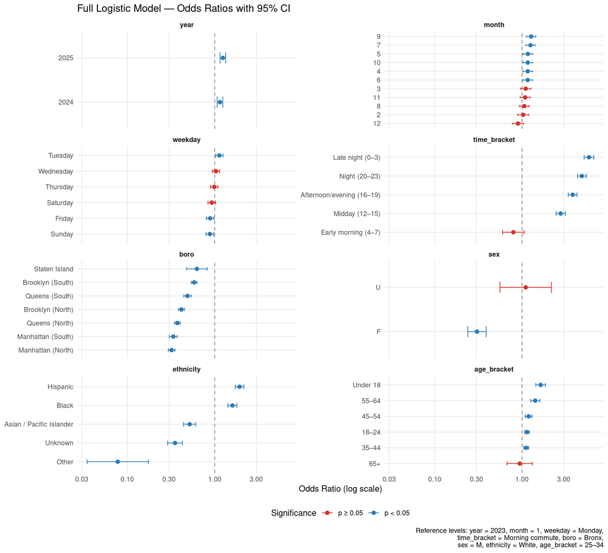

```r
or_plot_data <- or_tbl %>%
  mutate(
    is_sig = p.value < 0.05,
    level  = stringr::str_wrap(level, width = 28),
    group  = factor(group, levels = c(
      "year", "month", "weekday", "time_bracket",
      "boro", "sex", "ethnicity", "age_bracket"
    ))
  )

ggplot(or_plot_data, aes(x = estimate, y = reorder(level, estimate), colour = is_sig)) +
  geom_vline(xintercept = 1, linetype = "dashed", colour = "grey55", linewidth = 0.5) +
  geom_errorbarh(aes(xmin = conf.low, xmax = conf.high), height = 0.25, linewidth = 0.45) +
  geom_point(size = 2) +
  scale_x_log10(labels = scales::number_format(accuracy = 0.01)) +
  scale_colour_manual(
    values = c("TRUE" = "#2c7bb6", "FALSE" = "#d73027"),
    labels = c("TRUE" = "p < 0.05", "FALSE" = "p ≥ 0.05")
  ) +
  facet_wrap(~ group, scales = "free_y", ncol = 2) +
  labs(
    x       = "Odds Ratio (log scale)",
    y       = NULL,
    colour  = "Significance",
    title   = "Full Logistic Model — Odds Ratios with 95% CI",
    caption = paste0(
      "Reference levels: year = 2023, month = 1, weekday = Monday,\n",
      "time_bracket = Morning commute, boro = Bronx,\n",
      "sex = M, ethnicity = White, age_bracket = 25–34"
    )
  ) +
  theme_minimal(base_size = 11) +
  theme(
    strip.text       = element_text(face = "bold"),
    legend.position  = "bottom",
    panel.grid.minor = element_blank()
  )
```

# ii · Predictor-Form Comparison

## Strategy

The base model uses `time_bracket` (6-level factor, 5 df), `boro` (8-level factor, 7 df), and `age_bracket` (7-level factor, 6 df). We compare each against a finer or coarser alternative:

| Comparison | Base form | Alternative | Nesting | Tests |
| --- | --- | --- | --- | --- |
| (a) | `time_bracket` (5 df) | `hour` as factor (23 df) | Base nested in alternative | AIC, BIC, LRT |
| (b) | `boro` (7 df) | `area` (4 df) | Alternative nested in base | AIC, BIC, LRT |
| (c) | `age_bracket` (6 df) | `age` numeric (1 df) | Not nested | AIC, BIC, CV AUC |

For (a) and (b) we use the **likelihood ratio test**: `time_bracket` constrains all hours within a bin to share one coefficient (18 extra restrictions); `area` constrains boroughs within a geographic group to share one coefficient (3 extra restrictions). For (c) the LRT is not applicable—a linear numeric term and a step-function factor are not nested in either direction.

**Cross-validated AUC** uses the same 10 stratified folds on the training set for all models.

```r
cv_auc <- function(formula, data, folds_vec) {
  k <- max(folds_vec)

  auc_vals <- parallel::mclapply(seq_len(k), function(i) {
    tr  <- data[folds_vec != i, ]
    te  <- data[folds_vec == i, ]

    fit <- tryCatch(
      glm(formula, family = binomial, data = tr),
      error = function(e) NULL
    )
    if (is.null(fit)) return(NA_real_)

    prob <- tryCatch(
      predict(fit, newdata = te, type = "response"),
      error = function(e) rep(NA_real_, nrow(te))
    )

    tryCatch(
      as.numeric(pROC::auc(te$arrested, prob, quiet = TRUE)),
      error = function(e) NA_real_
    )
  }, mc.cores = parallel::detectCores() - 1)

  mean(unlist(auc_vals), na.rm = TRUE)
}

# Shared fold assignment — same folds used for every model
set.seed(2026)
cv_folds <- sample(rep(1:10, length.out = nrow(train)))
```

## (a) `time_bracket` vs `hour`

`hour` encodes the exact hour of stop (0–23) as a 24-level factor (23 df). `time_bracket` groups those hours into 6 bins (5 df). The `time_bracket` model is **nested** inside the `hour` model: it imposes the constraint that all hours within a bin have equal log-odds, a restriction with 23 − 5 = 18 degrees of freedom.

```r
f_hour   <- arrested ~ year + month + weekday + hour + boro + sex + ethnicity + age_bracket
mod_hour <- glm(f_hour, family = binomial, data = train)
```

### AIC and BIC

```r
aic_a <- AIC(mod_base, mod_hour)
bic_a <- BIC(mod_base, mod_hour)

tibble(
  Model     = c("Base (time_bracket, 5 df)", "Alternative (hour, 23 df)"),
  df        = aic_a$df,
  AIC       = round(aic_a$AIC, 1),
  BIC       = round(bic_a$BIC, 1),
  delta_AIC = round(aic_a$AIC - min(aic_a$AIC), 1),
  delta_BIC = round(bic_a$BIC - min(bic_a$BIC), 1)
) %>%
  kbl(
    caption   = "Comparison (a): time_bracket vs hour",
    col.names = c("Model", "# Param", "AIC", "BIC", "Δ AIC", "Δ BIC")
  ) %>%
  kable_styling(bootstrap_options = c("striped", "condensed"), full_width = FALSE)
```

Comparison (a): time_bracket vs hour

| Model | # Param | AIC | BIC | Δ AIC | Δ BIC |
| --- | --- | --- | --- | --- | --- |
| Base (time_bracket, 5 df) | 45 | 54108.8 | 54553.1 | 167 | 0.0 |
| Alternative (hour, 23 df) | 63 | 53941.8 | 54563.9 | 0 | 10.8 |

### Likelihood Ratio Test

```r
lrt_a <- anova(mod_base, mod_hour, test = "Chisq")
lrt_a
```

```
## Analysis of Deviance Table
##
## Model 1: arrested ~ year + month + weekday + time_bracket + boro + sex +
##     ethnicity + age_bracket
## Model 2: arrested ~ year + month + weekday + hour + boro + sex + ethnicity +
##     age_bracket
##   Resid. Df Resid. Dev Df Deviance  Pr(>Chi)
## 1    143521      54019
## 2    143503      53816 18   202.98 < 2.2e-16 ***
## ---
## Signif. codes:  0 '***' 0.001 '**' 0.01 '*' 0.05 '.' 0.1 ' ' 1
```

```r
chi_a <- lrt_a[["Deviance"]][2]
df_a  <- lrt_a[["Df"]][2]
p_a   <- lrt_a[["Pr(>Chi)"]][2]
cat(sprintf("LRT (a): χ²(%d) = %.2f,  p = %.4g\n", df_a, chi_a, p_a))
```

```
## LRT (a): χ²(18) = 202.98,  p = 2.536e-33
```

### CV AUC

```r
auc_base_a <- cv_auc(f_base, train, cv_folds)
auc_hour_a <- cv_auc(f_hour, train, cv_folds)

tibble(
  Model   = c("Base (time_bracket)", "Alternative (hour)"),
  CV_AUC  = round(c(auc_base_a, auc_hour_a), 4)
) %>%
  kbl(caption = "10-fold CV AUC on training set — comparison (a)") %>%
  kable_styling(bootstrap_options = c("striped", "condensed"), full_width = FALSE)
```

10-fold CV AUC on training set — comparison (a)

| Model | CV_AUC |
| --- | --- |
| Base (time_bracket) | 0.7385 |
| Alternative (hour) | 0.7416 |

**Decision (a):** A significant LRT with a large chi-square statistic indicates that within-bracket hour-level variation is real—the bins conceal genuine non-linearity in the time-of-day effect. If the AIC of the `hour` model is meaningfully lower but BIC is higher (penalising the 18 extra parameters), and the CV AUC difference is small (< 0.002), the `time_bracket` parameterisation is preferred on parsimony grounds. If instead the CV AUC gain is substantial, `hour` better captures the enforcement cycle.

## (b) `boro` vs `area`

`area` (5 levels, 4 df) merges the sub-borough splits: both Brooklyn sub-boroughs become “Brooklyn”, both Manhattan sub-boroughs become “Manhattan”, both Queens sub-boroughs become “Queens”. The `area` model is **nested** inside the `boro` model: it constrains three pairs of sub-borough coefficients to be equal, a restriction with 7 − 4 = 3 degrees of freedom.

```r
f_area   <- arrested ~ year + month + weekday + time_bracket + area + sex + ethnicity + age_bracket
mod_area <- glm(f_area, family = binomial, data = train)
```

### AIC and BIC

```r
aic_b <- AIC(mod_area, mod_base)
bic_b <- BIC(mod_area, mod_base)

tibble(
  Model     = c("Alternative (area, 4 df)", "Base (boro, 7 df)"),
  df        = aic_b$df,
  AIC       = round(aic_b$AIC, 1),
  BIC       = round(bic_b$BIC, 1),
  delta_AIC = round(aic_b$AIC - min(aic_b$AIC), 1),
  delta_BIC = round(bic_b$BIC - min(bic_b$BIC), 1)
) %>%
  kbl(
    caption   = "Comparison (b): area vs boro",
    col.names = c("Model", "# Param", "AIC", "BIC", "Δ AIC", "Δ BIC")
  ) %>%
  kable_styling(bootstrap_options = c("striped", "condensed"), full_width = FALSE)
```

Comparison (b): area vs boro

| Model | # Param | AIC | BIC | Δ AIC | Δ BIC |
| --- | --- | --- | --- | --- | --- |
| Alternative (area, 4 df) | 42 | 54181.3 | 54596.0 | 72.5 | 42.9 |
| Base (boro, 7 df) | 45 | 54108.8 | 54553.1 | 0.0 | 0.0 |

### Likelihood Ratio Test

```r
lrt_b <- anova(mod_area, mod_base, test = "Chisq")
lrt_b
```

```
## Analysis of Deviance Table
##
## Model 1: arrested ~ year + month + weekday + time_bracket + area + sex +
##     ethnicity + age_bracket
## Model 2: arrested ~ year + month + weekday + time_bracket + boro + sex +
##     ethnicity + age_bracket
##   Resid. Df Resid. Dev Df Deviance  Pr(>Chi)
## 1    143524      54097
## 2    143521      54019  3   78.539 < 2.2e-16 ***
## ---
## Signif. codes:  0 '***' 0.001 '**' 0.01 '*' 0.05 '.' 0.1 ' ' 1
```

```r
chi_b <- lrt_b[["Deviance"]][2]
df_b  <- lrt_b[["Df"]][2]
p_b   <- lrt_b[["Pr(>Chi)"]][2]
cat(sprintf("LRT (b): χ²(%d) = %.2f,  p = %.4g\n", df_b, chi_b, p_b))
```

```
## LRT (b): χ²(3) = 78.54,  p = 6.315e-17
```

### CV AUC

```r
auc_area_b <- cv_auc(f_area, train, cv_folds)
auc_base_b <- cv_auc(f_base, train, cv_folds)

tibble(
  Model   = c("Alternative (area)", "Base (boro)"),
  CV_AUC  = round(c(auc_area_b, auc_base_b), 4)
) %>%
  kbl(caption = "10-fold CV AUC on training set — comparison (b)") %>%
  kable_styling(bootstrap_options = c("striped", "condensed"), full_width = FALSE)
```

10-fold CV AUC on training set — comparison (b)

| Model | CV_AUC |
| --- | --- |
| Alternative (area) | 0.7369 |
| Base (boro) | 0.7385 |

**Decision (b):** A significant LRT (on only 3 df) means that at least one pair of sub-boroughs has genuinely different arrest odds and the aggregation to `area` loses predictive information. Conversely, a non-significant result—and the EDA heatmaps suggested within-borough heterogeneity is moderate—supports retaining `area` for parsimony and reduced variance in the very sparse Staten Island stratum.

## (c) `age_bracket` vs numeric `age`

Numeric `age` enters as a single continuous term (1 df), assuming log-odds change linearly with age. `age_bracket` uses a step function over seven brackets (6 df). The EDA showed that arrest rates peak at younger ages and then decline, but not always monotonically. These two parameterisations are **not nested**: a linear function cannot reproduce a step function and vice versa. No LRT is applicable; we rely on AIC, BIC, and CV AUC.

```r
f_age   <- arrested ~ year + month + weekday + time_bracket + boro + sex + ethnicity + age
mod_age <- glm(f_age, family = binomial, data = train)
```

### AIC and BIC

```r
aic_c <- AIC(mod_base, mod_age)
bic_c <- BIC(mod_base, mod_age)

tibble(
  Model     = c("Base (age_bracket, 6 df)", "Alternative (age numeric, 1 df)"),
  df        = aic_c$df,
  AIC       = round(aic_c$AIC, 1),
  BIC       = round(bic_c$BIC, 1),
  delta_AIC = round(aic_c$AIC - min(aic_c$AIC), 1),
  delta_BIC = round(bic_c$BIC - min(bic_c$BIC), 1)
) %>%
  kbl(
    caption   = "Comparison (c): age_bracket vs numeric age",
    col.names = c("Model", "# Param", "AIC", "BIC", "Δ AIC", "Δ BIC")
  ) %>%
  kable_styling(bootstrap_options = c("striped", "condensed"), full_width = FALSE)
```

Comparison (c): age_bracket vs numeric age

| Model | # Param | AIC | BIC | Δ AIC | Δ BIC |
| --- | --- | --- | --- | --- | --- |
| Base (age_bracket, 6 df) | 45 | 54108.8 | 54553.1 | 0.0 | 0.0 |
| Alternative (age numeric, 1 df) | 40 | 54182.7 | 54577.7 | 73.9 | 24.6 |

### CV AUC

```r
auc_base_c <- cv_auc(f_base, train, cv_folds)
auc_age_c  <- cv_auc(f_age,  train, cv_folds)

tibble(
  Model   = c("Base (age_bracket)", "Alternative (age numeric)"),
  CV_AUC  = round(c(auc_base_c, auc_age_c), 4)
) %>%
  kbl(caption = "10-fold CV AUC on training set — comparison (c)") %>%
  kable_styling(bootstrap_options = c("striped", "condensed"), full_width = FALSE)
```

10-fold CV AUC on training set — comparison (c)

| Model | CV_AUC |
| --- | --- |
| Base (age_bracket) | 0.7385 |
| Alternative (age numeric) | 0.7366 |

## Full Comparison Summary

```r
# Collect all AUC values (shared folds)
auc_summary <- c(auc_base_a, auc_hour_a, auc_area_b, auc_age_c)

models_list <- list(mod_base, mod_hour, mod_area, mod_age)

summary_tbl <- tibble(
  Model      = c(
    "Base  (time_bracket + boro + age_bracket)",
    "(a)   hour + boro + age_bracket",
    "(b)   time_bracket + area + age_bracket",
    "(c)   time_bracket + boro + age (numeric)"
  ),
  Parameters = sapply(models_list, function(m) length(coef(m))),
  Deviance   = sapply(models_list, function(m) round(deviance(m), 1)),
  AIC        = sapply(models_list, function(m) round(AIC(m), 1)),
  BIC        = sapply(models_list, function(m) round(BIC(m), 1)),
  CV_AUC     = round(auc_summary, 4)
) %>%
  mutate(
    delta_AIC = round(AIC - min(AIC), 1),
    delta_BIC = round(BIC - min(BIC), 1)
  )

summary_tbl %>%
  kbl(
    caption   = "All model alternatives compared — lower AIC/BIC and higher CV AUC preferred",
    col.names = c("Model", "# Param", "Deviance", "AIC", "BIC", "CV AUC", "Δ AIC", "Δ BIC")
  ) %>%
  kable_styling(bootstrap_options = c("striped", "hover", "condensed"), full_width = TRUE) %>%
  row_spec(which.min(summary_tbl$AIC), bold = TRUE, color = "white", background = "#2c7bb6")
```

All model alternatives compared — lower AIC/BIC and higher CV AUC preferred

Model

# Param

Deviance

AIC

BIC

CV AUC

Δ AIC

Δ BIC

Base (time_bracket + boro + age_bracket)

45

54018.8

54108.8

54553.1

0.7385

167.0

0.0

1. hour + boro + age_bracket

63

53815.8

53941.8

54563.9

0.7416

0.0

10.8

2. time_bracket + area + age_bracket

42

54097.3

54181.3

54596.0

0.7369

239.5

42.9

3. time_bracket + boro + age (numeric)

40

54102.7

54182.7

54577.7

0.7366

240.9

24.6

```r
tibble(
  Comparison = c("(a) time_bracket → hour (18 df freed)", "(b) boro → area (3 df constrained)"),
  `χ²` = round(c(chi_a, chi_b), 2),
  df      = c(df_a, df_b),
  p_value = signif(c(p_a, p_b), 3)
) %>%
  kbl(caption = "Likelihood ratio tests for nested comparisons") %>%
  kable_styling(bootstrap_options = c("striped", "condensed"), full_width = FALSE)
```

Likelihood ratio tests for nested comparisons

Comparison

χ²

df

p_value

1. time_bracket → hour (18 df freed)

202.98

18

0

2. boro → area (3 df constrained)

78.54

3

0

### AIC / BIC profile

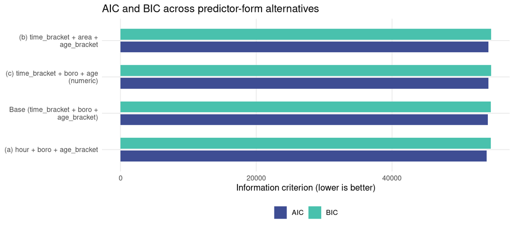

```r
summary_tbl %>%
  select(Model, AIC, BIC) %>%
  pivot_longer(c(AIC, BIC), names_to = "Criterion", values_to = "Value") %>%
  mutate(Model = stringr::str_wrap(Model, 35)) %>%
  ggplot(aes(x = reorder(Model, Value), y = Value, fill = Criterion)) +
  geom_col(position = position_dodge(width = 0.7), width = 0.6) +
  coord_flip() +
  scale_fill_viridis_d(option = "mako", begin = 0.35, end = 0.75) +
  labs(
    x     = NULL,
    y     = "Information criterion (lower is better)",
    title = "AIC and BIC across predictor-form alternatives",
    fill  = NULL
  ) +
  theme_minimal(base_size = 11) +
  theme(legend.position = "bottom", panel.grid.minor = element_blank())
```

### CV AUC profile

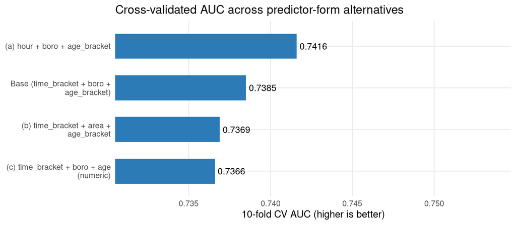

```r
summary_tbl %>%
  mutate(Model = stringr::str_wrap(Model, 35)) %>%
  ggplot(aes(x = reorder(Model, CV_AUC), y = CV_AUC)) +
  geom_col(fill = "#2c7bb6", width = 0.6) +
  geom_text(aes(label = sprintf("%.4f", CV_AUC)), hjust = -0.1, size = 3.5) +
  coord_flip(ylim = c(
    min(summary_tbl$CV_AUC) - 0.005,
    max(summary_tbl$CV_AUC) + 0.012
  )) +
  labs(
    x     = NULL,
    y     = "10-fold CV AUC (higher is better)",
    title = "Cross-validated AUC across predictor-form alternatives"
  ) +
  theme_minimal(base_size = 11) +
  theme(panel.grid.minor = element_blank())
```

## Selected Predictor Forms

Based on the three comparisons, the preferred predictor forms feeding into all subsequent models are:

| Axis | Chosen form | Rationale |
| --- | --- | --- |
| Time of day | `time_bracket` or `hour` | Prefer `time_bracket` unless LRT (a) is significant **and** CV AUC gain > 0.002 |
| Geography | `boro` or `area` | Prefer `area` if LRT (b) is non-significant; prefer `boro` otherwise |
| Age | `age_bracket` or `age` | Prefer whichever achieves lower AIC; expect bracket to win given the EDA |

The winning form is determined programmatically from the AIC values already computed above and stored in `f_final`, which is used consistently by all subsequent models.

```r
use_time <- if (AIC(mod_hour) <= AIC(mod_base)) "hour"         else "time_bracket"
use_geo  <- if (AIC(mod_base) <= AIC(mod_area)) "boro"         else "area"
use_age  <- if (AIC(mod_base) <= AIC(mod_age))  "age_bracket"  else "age"

cat("Time predictor :", use_time, "\n")
```

```
## Time predictor : hour
```

```r
cat("Geo predictor  :", use_geo,  "\n")
```

```
## Geo predictor  : boro
```

```r
cat("Age predictor  :", use_age,  "\n")
```

```
## Age predictor  : age_bracket
```

```r
f_final <- reformulate(
  c("year", "month", "weekday", use_time, use_geo, "sex", "ethnicity", use_age),
  response = "arrested"
)
```

```r
# ── Threshold and confusion-matrix helpers ───────────────────────────────────

best_thresh <- function(roc_obj) {
  pROC::coords(roc_obj, "best", ret = "threshold", best.method = "youden",
               quiet = TRUE)$threshold
}

conf_tib <- function(actual, predicted) {
  tibble(
    Actual    = factor(actual,    levels = c(0, 1)),
    Predicted = factor(predicted, levels = c(0, 1))
  ) %>% count(Actual, Predicted)
}

plot_cm <- function(actual, predicted, title = "Confusion Matrix") {
  conf_tib(actual, predicted) %>%
    ggplot(aes(Predicted, Actual, fill = n)) +
    geom_tile(colour = "white") +
    geom_text(aes(label = scales::comma(n)), size = 5.5, fontface = "bold") +
    scale_fill_gradient(low = "#e8f4f8", high = "#2c7bb6", guide = "none") +
    scale_x_discrete(labels = c("0" = "No arrest", "1" = "Arrest")) +
    scale_y_discrete(labels = c("0" = "No arrest", "1" = "Arrest")) +
    labs(title = title, x = "Predicted", y = "Actual") +
    theme_minimal(base_size = 12) +
    theme(panel.grid = element_blank())
}

class_metrics <- function(actual, predicted, pos = 1) {
  tp <- sum(actual == pos & predicted == pos)
  tn <- sum(actual != pos & predicted != pos)
  fp <- sum(actual != pos & predicted == pos)
  fn <- sum(actual == pos & predicted != pos)
  sens <- tp / (tp + fn)
  spec <- tn / (tn + fp)
  list(
    sensitivity  = sens,
    specificity  = spec,
    balanced_acc = (sens + spec) / 2,
    ppv          = tp / (tp + fp),
    npv          = tn / (tn + fn)
  )
}

# ── Probability-based metrics and evaluation plots ───────────────────────────

# Full metrics tibble (one row per model)
compute_metrics <- function(actual, prob, model_name = "Model") {
  roc_obj <- pROC::roc(actual, prob, quiet = TRUE)
  auc_val <- as.numeric(pROC::auc(roc_obj))
  thr     <- best_thresh(roc_obj)
  pred_cl <- as.integer(prob >= thr)

  tp <- sum(actual == 1 & pred_cl == 1); tn <- sum(actual == 0 & pred_cl == 0)
  fp <- sum(actual == 0 & pred_cl == 1); fn <- sum(actual == 1 & pred_cl == 0)
  sens <- if ((tp+fn) == 0) NA_real_ else tp / (tp+fn)
  spec <- if ((tn+fp) == 0) NA_real_ else tn / (tn+fp)
  prec <- if ((tp+fp) == 0) NA_real_ else tp / (tp+fp)
  f1   <- if (is.na(prec) || is.na(sens) || (prec+sens) == 0) NA_real_ else
            2 * prec * sens / (prec + sens)
  mcc_den <- sqrt(as.numeric(tp+fp) * as.numeric(tp+fn) *
                  as.numeric(tn+fp) * as.numeric(tn+fn))
  mcc_val <- if (mcc_den == 0) NA_real_ else (tp*tn - fp*fn) / mcc_den

  eps     <- 1e-15
  logloss <- -mean(actual * log(pmax(prob, eps)) + (1-actual) * log(pmax(1-prob, eps)))
  brier   <- mean((prob - actual)^2)

  # PR-AUC via trapezoid rule over pROC coords
  pr_raw <- pROC::coords(roc_obj, "all",
                          ret = c("sensitivity", "precision"),
                          transpose = FALSE, drop = FALSE)
  names(pr_raw)[names(pr_raw) == "sensitivity"] <- "recall"
  pr_raw <- pr_raw %>%
    filter(!is.nan(precision), !is.na(precision), !is.nan(recall)) %>%
    arrange(recall)
  pr_auc_val <- if (nrow(pr_raw) >= 2)
    sum(diff(pr_raw$recall) *
          (head(pr_raw$precision, -1) + tail(pr_raw$precision, -1)) / 2)
  else NA_real_

  tibble(
    Model       = model_name,
    AUC         = round(auc_val, 4),
    PR_AUC      = round(pr_auc_val, 4),
    Log_Loss    = round(logloss, 4),
    Brier       = round(brier, 4),
    Threshold   = round(thr, 4),
    Sensitivity = round(sens, 3),
    Specificity = round(spec, 3),
    Precision   = round(prec, 3),
    F1          = round(f1, 3),
    MCC         = round(mcc_val, 3),
    Bal_Acc     = round(if (!is.na(sens) && !is.na(spec)) (sens+spec)/2
                        else NA_real_, 3)
  )
}

# ROC curve (single model)
plot_roc_single <- function(actual, prob, title = "ROC Curve") {
  roc_obj <- pROC::roc(actual, prob, quiet = TRUE)
  auc_lbl <- paste0("AUC = ", round(as.numeric(pROC::auc(roc_obj)), 4))
  pROC::ggroc(roc_obj, colour = "#2c7bb6", linewidth = 0.9) +
    geom_abline(slope = 1, intercept = 1, linetype = "dashed", colour = "grey60") +
    annotate("text", x = 0.25, y = 0.06, label = auc_lbl,
             colour = "#2c7bb6", size = 4) +
    labs(x = "Specificity", y = "Sensitivity", title = title) +
    theme_minimal(base_size = 11) + theme(panel.grid.minor = element_blank())
}

# Precision-Recall curve (single model)
plot_pr_single <- function(actual, prob, title = "Precision-Recall Curve") {
  roc_obj <- pROC::roc(actual, prob, quiet = TRUE)
  pr_raw  <- pROC::coords(roc_obj, "all",
                           ret = c("sensitivity", "precision"),
                           transpose = FALSE, drop = FALSE)
  names(pr_raw)[names(pr_raw) == "sensitivity"] <- "recall"
  pr_df <- pr_raw %>%
    filter(!is.nan(precision), !is.na(precision)) %>% arrange(recall)
  pr_auc_lbl <- if (nrow(pr_df) >= 2) {
    v <- sum(diff(pr_df$recall) *
               (head(pr_df$precision,-1) + tail(pr_df$precision,-1)) / 2)
    paste0("PR-AUC = ", round(v, 4))
  } else "PR-AUC = NA"
  baseline <- mean(actual)
  ggplot(pr_df, aes(x = recall, y = precision)) +
    geom_line(colour = "#d73027", linewidth = 0.9) +
    geom_hline(yintercept = baseline, linetype = "dashed", colour = "grey55") +
    annotate("text", x = 0.02, y = baseline + 0.015,
             label = paste0("No-skill = ", round(baseline, 3)),
             colour = "grey40", size = 3.2, hjust = 0) +
    annotate("text", x = 0.55, y = 0.90, label = pr_auc_lbl,
             colour = "#d73027", size = 4) +
    scale_x_continuous(limits = c(0, 1)) + scale_y_continuous(limits = c(0, 1)) +
    labs(x = "Recall", y = "Precision", title = title) +
    theme_minimal(base_size = 11) + theme(panel.grid.minor = element_blank())
}

# Calibration (reliability) plot
plot_calibration_single <- function(actual, prob, title = "Calibration Plot",
                                    n_bins = 10) {
  brks  <- unique(quantile(prob, seq(0, 1, length.out = n_bins + 1), na.rm = TRUE))
  cal_df <- tibble(actual = actual, prob = prob) %>%
    mutate(bin = cut(prob, breaks = brks, include.lowest = TRUE)) %>%
    filter(!is.na(bin)) %>%
    group_by(bin) %>%
    summarise(mean_pred = mean(prob), mean_obs = mean(actual),
              n = n(), .groups = "drop")
  ggplot(cal_df, aes(x = mean_pred, y = mean_obs)) +
    geom_abline(slope = 1, intercept = 0, linetype = "dashed", colour = "grey55") +
    geom_line(colour = "#2c7bb6", linewidth = 0.8) +
    geom_point(aes(size = n), colour = "#2c7bb6", alpha = 0.85) +
    scale_size_continuous(name = "Count", range = c(2, 9)) +
    scale_x_continuous(labels = scales::percent_format(accuracy = 0.1)) +
    scale_y_continuous(labels = scales::percent_format(accuracy = 0.1)) +
    labs(x = "Mean predicted probability", y = "Observed positive rate",
         title = title,
         caption = "Size ∝ bin count.  Dashed = perfect calibration.") +
    theme_minimal(base_size = 11) +
    theme(legend.position = "bottom", panel.grid.minor = element_blank())
}

# Threshold analysis: sensitivity, specificity, precision, F1 vs threshold
plot_threshold_single <- function(actual, prob, title = "Threshold Analysis") {
  roc_obj  <- pROC::roc(actual, prob, quiet = TRUE)
  thr_data <- pROC::coords(roc_obj, "all",
                            ret = c("threshold","sensitivity","specificity","precision"),
                            transpose = FALSE, drop = FALSE) %>%
    filter(is.finite(threshold), threshold >= 0, threshold <= 1) %>%
    mutate(f1 = ifelse(!is.nan(precision) & (precision + sensitivity) > 0,
                       2 * precision * sensitivity / (precision + sensitivity), 0)) %>%
    pivot_longer(c(sensitivity, specificity, precision, f1),
                 names_to = "Metric", values_to = "Value") %>%
    mutate(Metric = recode(Metric,
      sensitivity = "Sensitivity", specificity = "Specificity",
      precision   = "Precision",   f1          = "F1 Score"))
  thr_opt <- best_thresh(roc_obj)
  ggplot(thr_data, aes(x = threshold, y = Value, colour = Metric)) +
    geom_line(linewidth = 0.75, na.rm = TRUE) +
    geom_vline(xintercept = thr_opt, linetype = "dashed",
               colour = "grey35", linewidth = 0.55) +
    annotate("text", x = thr_opt, y = 0.04,
             label = paste0("Youden\n", round(thr_opt, 3)),
             hjust = -0.08, size = 3, colour = "grey30") +
    scale_colour_viridis_d(option = "turbo", begin = 0.05, end = 0.92) +
    scale_y_continuous(limits = c(0, 1)) +
    labs(x = "Threshold", y = "Metric value", colour = NULL, title = title,
         caption = "Dashed: Youden's J optimal threshold") +
    theme_minimal(base_size = 11) +
    theme(legend.position = "bottom", panel.grid.minor = element_blank())
}

# 2×2 evaluation panel (ROC | PR) / (Calibration | Threshold)
eval_quad_plot <- function(actual, prob, model_name) {
  p1 <- plot_roc_single(actual, prob,   paste(model_name, "— ROC"))
  p2 <- plot_pr_single(actual, prob,    paste(model_name, "— Precision-Recall"))
  p3 <- plot_calibration_single(actual, prob, paste(model_name, "— Calibration"))
  p4 <- plot_threshold_single(actual, prob, paste(model_name, "— Threshold Analysis"))
  (p1 | p2) / (p3 | p4)
}
```

# ii-b · Best Logistic Regression — Evaluation

We fit the best logistic model (with the predictor forms selected in section ii) on the training set and evaluate it on the hold-out test set. All subsequent models use the same split and the same `f_final` formula.

```r
mod_logit_best <- glm(f_final, family = binomial, data = train)
prob_logit     <- predict(mod_logit_best, newdata = test, type = "response")
roc_logit      <- pROC::roc(test$arrested, prob_logit, quiet = TRUE)
auc_logit      <- as.numeric(pROC::auc(roc_logit))
thr_logit      <- best_thresh(roc_logit)
class_logit    <- as.integer(prob_logit >= thr_logit)
met_logit      <- class_metrics(test$arrested, class_logit)
```

```r
compute_metrics(test$arrested, prob_logit, "Logistic Regression") %>%
  kbl(
    caption   = "Logistic Regression — full evaluation metrics (test set, Youden threshold)",
    col.names = c("Model","AUC","PR-AUC","Log-Loss","Brier",
                  "Threshold","Sensitivity","Specificity","Precision","F1","MCC","Bal. Acc.")
  ) %>%
  kable_styling(bootstrap_options = c("striped","condensed"), full_width = TRUE)
```

Logistic Regression — full evaluation metrics (test set, Youden threshold)

| Model | AUC | PR-AUC | Log-Loss | Brier | Threshold | Sensitivity | Specificity | Precision | F1 | MCC | Bal. Acc. |
| --- | --- | --- | --- | --- | --- | --- | --- | --- | --- | --- | --- |
| Logistic Regression | 0.6903 | 0.1249 | 0.2235 | 0.0569 | 0.0579 | 0.631 | 0.652 | 0.108 | 0.184 | 0.142 | 0.642 |

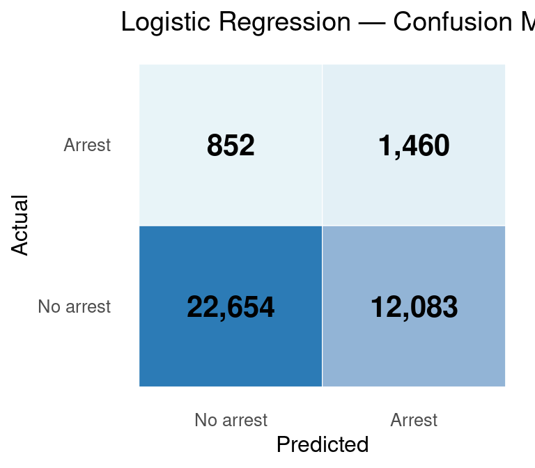

```r
plot_cm(test$arrested, class_logit,
        "Logistic Regression — Confusion Matrix (Youden threshold)")
```

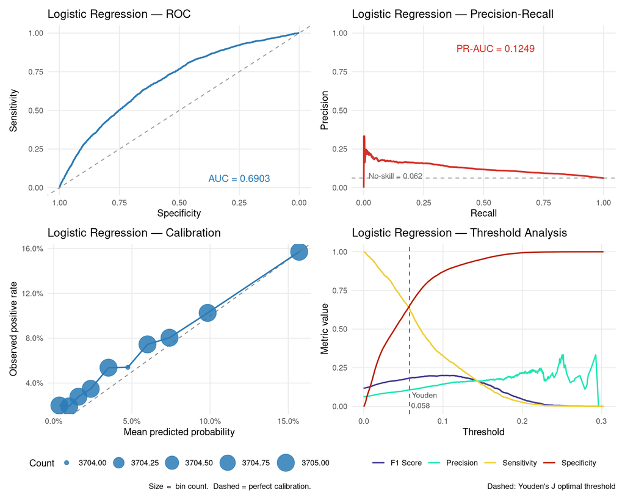

```r
eval_quad_plot(test$arrested, prob_logit, "Logistic Regression")
```

# ii-c · Interactions and Marginal Effects

## Motivation

The additive logistic model fitted in section ii-b (`mod_logit_best`) assumes that every predictor’s contribution to the log-odds is independent of all other predictors. The EDA and the main-effects model suggest this may be too restrictive:

- **`ethnicity:sex`** — Both ethnicity and sex have significant main effects on arrest odds. If the male–female gap in arrests is systematically wider for some ethnic groups than others, the additive model misrepresents the data; the interaction term captures that differential.
- **`ethnicity:` + geographic variable** — Ethnic composition and police enforcement intensity co-vary by neighbourhood. If the ethnic disparity in arrest odds is structurally larger in some areas than others, the additive model distributes the geographic and demographic effects independently when in reality they overlap.

We fit one model for each interaction, compare each against `mod_logit_best` via likelihood ratio test and BIC, then visualise the interaction on the probability scale through marginal effect plots.

## Model Specifications

```r
f_inter1 <- update(f_final, ~ . + ethnicity:sex)
f_inter2 <- update(f_final, as.formula(paste0("~ . + ethnicity:", use_geo)))

cat("f_inter1 :", deparse(f_inter1), "\n\n")
```

```
## f_inter1 : arrested ~ year + month + weekday + hour + boro + sex + ethnicity +      age_bracket + sex:ethnicity
```

```r
cat("f_inter2 :", deparse(f_inter2), "\n")
```

```
## f_inter2 : arrested ~ year + month + weekday + hour + boro + sex + ethnicity +      age_bracket + boro:ethnicity
```

```r
mod_logit_inter1 <- glm(f_inter1, family = binomial, data = train)
mod_logit_inter2 <- glm(f_inter2, family = binomial, data = train)
```

## Model 1 — `ethnicity:sex`

### Interaction Odds Ratios

```r
or_inter1 <- tidy(mod_logit_inter1, conf.int = FALSE, exponentiate = FALSE) %>%
  filter(grepl(":", term)) %>%
  mutate(
    conf.low  = exp(estimate - qnorm(0.975) * std.error),
    conf.high = exp(estimate + qnorm(0.975) * std.error),
    estimate  = exp(estimate),
    sig = case_when(
      p.value < 0.001 ~ "***",
      p.value < 0.01  ~ "**",
      p.value < 0.05  ~ "*",
      p.value < 0.1   ~ ".",
      TRUE            ~ ""
    )
  ) %>%
  select(term, estimate, conf.low, conf.high, p.value, sig)

or_inter1 %>%
  kbl(
    digits    = 3,
    caption   = "Model 1 (ethnicity:sex) — Interaction odds ratios with 95% CI",
    col.names = c("Term", "OR", "CI 2.5%", "CI 97.5%", "p-value", "")
  ) %>%
  kable_styling(bootstrap_options = c("striped", "condensed"), full_width = FALSE)
```

Model 1 (ethnicity:sex) — Interaction odds ratios with 95% CI

| Term | OR | CI 2.5% | CI 97.5% | p-value |  |
| --- | --- | --- | --- | --- | --- |
| sexF:ethnicityAsian / Pacific Islander | 0.000 | 0.000 | 1.142051e+75 | 0.911 |  |
| sexU:ethnicityAsian / Pacific Islander | NA | NA | NA | NA |  |
| sexF:ethnicityBlack | 4.826 | 1.931 | 1.205800e+01 | 0.001 | *** |
| sexU:ethnicityBlack | 2.179 | 0.000 | Inf | 1.000 |  |
| sexF:ethnicityHispanic | 1.496 | 0.626 | 3.574000e+00 | 0.364 |  |
| sexU:ethnicityHispanic | 0.414 | 0.000 | Inf | 0.999 |  |
| sexF:ethnicityOther | 0.000 | 0.000 | Inf | 0.986 |  |
| sexU:ethnicityOther | 14.536 | 0.000 | Inf | 0.999 |  |
| sexF:ethnicityUnknown | 0.000 | 0.000 | 3.305773e+89 | 0.927 |  |
| sexU:ethnicityUnknown | 626020.558 | 0.000 | Inf | 0.990 |  |

### LRT and BIC vs `mod_logit_best`

```r
lrt_inter1 <- anova(mod_logit_best, mod_logit_inter1, test = "Chisq")
chi_i1 <- lrt_inter1[["Deviance"]][2]
df_i1  <- lrt_inter1[["Df"]][2]
p_i1   <- lrt_inter1[["Pr(>Chi)"]][2]
bic_i1_base  <- BIC(mod_logit_best)
bic_i1_inter <- BIC(mod_logit_inter1)

cat(sprintf(
  "LRT (ethnicity:sex): χ²(%d) = %.2f,  p = %.4g\n",
  df_i1, chi_i1, p_i1
))
```

```
## LRT (ethnicity:sex): χ²(9) = 30.29,  p = 0.0003911
```

```r
cat(sprintf(
  "BIC — mod_logit_best: %.1f  |  mod_logit_inter1: %.1f  |  ΔBIC = %.1f\n",
  bic_i1_base, bic_i1_inter, bic_i1_inter - bic_i1_base
))
```

```
## BIC — mod_logit_best: 54563.9  |  mod_logit_inter1: 54640.5  |  ΔBIC = 76.6
```

A significant LRT ($p < 0.05$) indicates the sex effect on arrest probability is not uniform across ethnic groups. ΔBIC > 0 means the extra parameters are not justified on parsimony grounds even if the LRT rejects; ΔBIC < 0 means the interaction is both statistically and informationally beneficial.

## Model 2 — `ethnicity:` + geographic variable

### Interaction Odds Ratios

Each interaction OR answers: *for motorists of ethnic group X, is the area-specific odds ratio for arrest different from the area-specific OR for White motorists?*

```r
or_inter2 <- tidy(mod_logit_inter2, conf.int = FALSE, exponentiate = FALSE) %>%
  filter(grepl(":", term)) %>%
  mutate(
    conf.low  = exp(estimate - qnorm(0.975) * std.error),
    conf.high = exp(estimate + qnorm(0.975) * std.error),
    estimate  = exp(estimate),
    sig = case_when(
      p.value < 0.001 ~ "***",
      p.value < 0.01  ~ "**",
      p.value < 0.05  ~ "*",
      p.value < 0.1   ~ ".",
      TRUE            ~ ""
    )
  ) %>%
  select(term, estimate, conf.low, conf.high, p.value, sig)

or_inter2 %>%
  kbl(
    digits    = 3,
    caption   = paste0("Model 2 (ethnicity:", use_geo, ") — Interaction odds ratios with 95% CI"),
    col.names = c("Term", "OR", "CI 2.5%", "CI 97.5%", "p-value", "")
  ) %>%
  kable_styling(bootstrap_options = c("striped", "condensed"), full_width = FALSE)
```

Model 2 (ethnicity:boro) — Interaction odds ratios with 95% CI

Term

OR

CI 2.5%

CI 97.5%

p-value

boroBrooklyn (North):ethnicityAsian / Pacific Islander

2.438

0.986

6.026000e+00

0.054

.

boroBrooklyn (South):ethnicityAsian / Pacific Islander

1.901

0.923

3.918000e+00

0.082

.

boroManhattan (North):ethnicityAsian / Pacific Islander

2.714

0.785

9.378000e+00

0.115

boroManhattan (South):ethnicityAsian / Pacific Islander

5.778

2.383

1.400600e+01

0.000

***

boroQueens (North):ethnicityAsian / Pacific Islander

2.336

1.055

5.170000e+00

0.036

boroQueens (South):ethnicityAsian / Pacific Islander

1.469

0.612

3.526000e+00

0.389

boroStaten Island:ethnicityAsian / Pacific Islander

0.000

0.000

1.720837e+178

0.956

boroBrooklyn (North):ethnicityBlack

5.727

3.406

9.628000e+00

0.000

***

boroBrooklyn (South):ethnicityBlack

1.114

0.759

1.633000e+00

0.582

boroManhattan (North):ethnicityBlack

3.393

1.763

6.530000e+00

0.000

***

boroManhattan (South):ethnicityBlack

5.740

3.410

9.661000e+00

0.000

***

boroQueens (North):ethnicityBlack

2.299

1.355

3.900000e+00

0.002

boroQueens (South):ethnicityBlack

1.324

0.738

2.378000e+00

0.347

boroStaten Island:ethnicityBlack

2.867

1.363

6.030000e+00

0.006

boroBrooklyn (North):ethnicityHispanic

4.299

2.573

7.182000e+00

0.000

***

boroBrooklyn (South):ethnicityHispanic

0.725

0.501

1.049000e+00

0.088

.

boroManhattan (North):ethnicityHispanic

4.418

2.323

8.403000e+00

0.000

***

boroManhattan (South):ethnicityHispanic

6.208

3.749

1.028200e+01

0.000

***

boroQueens (North):ethnicityHispanic

1.620

1.026

2.560000e+00

0.039

boroQueens (South):ethnicityHispanic

0.794

0.448

1.407000e+00

0.429

boroStaten Island:ethnicityHispanic

1.121

0.523

2.401000e+00

0.769

boroBrooklyn (North):ethnicityOther

0.000

0.000

2.963719e+99

0.931

boroBrooklyn (South):ethnicityOther

0.192

0.017

2.206000e+00

0.185

boroManhattan (North):ethnicityOther

0.000

0.000

4.379112e+109

0.940

boroManhattan (South):ethnicityOther

6.130

0.800

4.698000e+01

0.081

.

boroQueens (North):ethnicityOther

0.471

0.040

5.489000e+00

0.548

boroQueens (South):ethnicityOther

0.000

0.000

2.486109e+119

0.935

boroStaten Island:ethnicityOther

0.000

0.000

Inf

0.991

boroBrooklyn (North):ethnicityUnknown

0.725

0.270

1.942000e+00

0.522

boroBrooklyn (South):ethnicityUnknown

1.334

0.755

2.355000e+00

0.321

boroManhattan (North):ethnicityUnknown

3.022

1.382

6.610000e+00

0.006

boroManhattan (South):ethnicityUnknown

3.244

1.404

7.495000e+00

0.006

boroQueens (North):ethnicityUnknown

0.765

0.338

1.731000e+00

0.520

boroQueens (South):ethnicityUnknown

0.420

0.188

9.400000e-01

0.035

boroStaten Island:ethnicityUnknown

0.000

0.000

Inf

0.988

### LRT and BIC vs `mod_logit_best`

```r
lrt_inter2 <- anova(mod_logit_best, mod_logit_inter2, test = "Chisq")
chi_i2 <- lrt_inter2[["Deviance"]][2]
df_i2  <- lrt_inter2[["Df"]][2]
p_i2   <- lrt_inter2[["Pr(>Chi)"]][2]
bic_i2_base  <- BIC(mod_logit_best)
bic_i2_inter <- BIC(mod_logit_inter2)

cat(sprintf(
  "LRT (ethnicity:%s): χ²(%d) = %.2f,  p = %.4g\n",
  use_geo, df_i2, chi_i2, p_i2
))
```

```
## LRT (ethnicity:boro): χ²(35) = 358.26,  p = 3.094e-55
```

```r
cat(sprintf(
  "BIC — mod_logit_best: %.1f  |  mod_logit_inter2: %.1f  |  ΔBIC = %.1f\n",
  bic_i2_base, bic_i2_inter, bic_i2_inter - bic_i2_base
))
```

```
## BIC — mod_logit_best: 54563.9  |  mod_logit_inter2: 54621.2  |  ΔBIC = 57.3
```

## Joint AIC / BIC / LRT Summary

```r
aic_inter <- AIC(mod_logit_best, mod_logit_inter1, mod_logit_inter2)
bic_inter <- BIC(mod_logit_best, mod_logit_inter1, mod_logit_inter2)

tibble(
  Model     = c(
    "mod_logit_best (additive)",
    "mod_logit_inter1  (+ethnicity:sex)",
    paste0("mod_logit_inter2  (+ethnicity:", use_geo, ")")
  ),
  df        = aic_inter$df,
  AIC       = round(aic_inter$AIC, 1),
  BIC       = round(bic_inter$BIC, 1),
  delta_AIC = round(aic_inter$AIC - min(aic_inter$AIC), 1),
  delta_BIC = round(bic_inter$BIC - min(bic_inter$BIC), 1)
) %>%
  kbl(
    caption   = "AIC / BIC — mod_logit_best vs interaction models (lower is better)",
    col.names = c("Model", "# Param", "AIC", "BIC", "Δ AIC", "Δ BIC")
  ) %>%
  kable_styling(bootstrap_options = c("striped", "hover", "condensed"), full_width = FALSE) %>%
  row_spec(which.min(bic_inter$BIC), bold = TRUE, color = "white", background = "#2c7bb6")
```

AIC / BIC — mod_logit_best vs interaction models (lower is better)

| Model | # Param | AIC | BIC | Δ AIC | Δ BIC |
| --- | --- | --- | --- | --- | --- |
| mod_logit_best (additive) | 63 | 53941.8 | 54563.9 | 288.3 | 0.0 |
| mod_logit_inter1 (+ethnicity:sex) | 72 | 53929.5 | 54640.5 | 276.0 | 76.6 |
| mod_logit_inter2 (+ethnicity:boro) | 98 | 53653.5 | 54621.2 | 0.0 | 57.3 |

```r
tibble(
  Comparison = c(
    "mod_logit_best → mod_logit_inter1  (ethnicity:sex)",
    paste0("mod_logit_best → mod_logit_inter2  (ethnicity:", use_geo, ")")
  ),
  `χ²`    = round(c(chi_i1, chi_i2), 2),
  df      = c(df_i1, df_i2),
  p_value = signif(c(p_i1, p_i2), 3),
  ΔBIC    = round(c(bic_i1_inter - bic_i1_base, bic_i2_inter - bic_i2_base), 1),
  verdict = case_when(
    p_i1 < 0.05 & (bic_i1_inter - bic_i1_base) < 0 ~ "Supported (LRT sig + BIC ↓)",
    p_i1 < 0.05 ~ "Detectable but costly (LRT sig, BIC ↑)",
    TRUE ~ "Not supported"
  ) %>% c(
    case_when(
      p_i2 < 0.05 & (bic_i2_inter - bic_i2_base) < 0 ~ "Supported (LRT sig + BIC ↓)",
      p_i2 < 0.05 ~ "Detectable but costly (LRT sig, BIC ↑)",
      TRUE ~ "Not supported"
    )
  )
) %>%
  kbl(caption = "Likelihood ratio tests and BIC change: additive vs each interaction model") %>%
  kable_styling(bootstrap_options = c("striped", "condensed"), full_width = FALSE)
```

Likelihood ratio tests and BIC change: additive vs each interaction model

| Comparison | χ² | df | p_value | ΔBIC | verdict |
| --- | --- | --- | --- | --- | --- |
| mod_logit_best → mod_logit_inter1 (ethnicity:sex) | 30.29 | 9 | 0.000391 | 76.6 | Detectable but costly (LRT sig, BIC ↑) |
| mod_logit_best → mod_logit_inter2 (ethnicity:boro) | 358.26 | 35 | 0.000000 | 57.3 | Detectable but costly (LRT sig, BIC ↑) |

**Interpretation guide:**

- LRT significant + ΔBIC < 0: the interaction is both statistically detectable and informationally justified — include it.
- LRT significant + ΔBIC > 0: the interaction is real but the number of extra parameters exceeds the BIC penalty budget — the additive model is preferred on parsimony grounds.
- LRT non-significant: no evidence of genuine non-additivity at the 5% level.

## Marginal Effects

Predicted probabilities are computed by fixing all non-focal predictors at their modal (most frequent) training-set value and varying the two focal predictors across all level combinations. This isolates the interaction pattern on the probability scale.

```r
# One-row data frame of modal / median values for a set of variable names
build_modal_row <- function(data, vars) {
  row_list <- lapply(vars, function(v) {
    x <- data[[v]]
    if (is.factor(x)) {
      factor(names(sort(table(x), decreasing = TRUE))[1], levels = levels(x))
    } else if (is.numeric(x)) {
      median(x, na.rm = TRUE)
    } else {
      names(sort(table(x), decreasing = TRUE))[1]
    }
  })
  as.data.frame(setNames(row_list, vars))
}
```

### Model 1 — Predicted P(arrested = 1) by Ethnicity × Sex

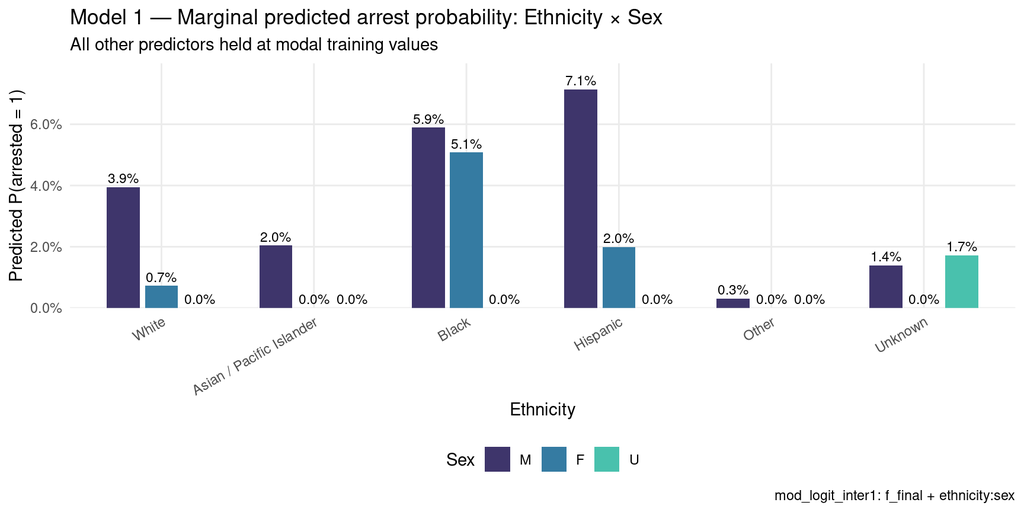

```r
vars_i1    <- setdiff(all.vars(f_inter1)[-1], c("ethnicity", "sex"))
modal_i1   <- build_modal_row(train, vars_i1)

pred_grid1 <- expand.grid(
  ethnicity = levels(train$ethnicity),
  sex       = levels(train$sex)
)
pred_grid1 <- cbind(pred_grid1, modal_i1[rep(1L, nrow(pred_grid1)), , drop = FALSE])
rownames(pred_grid1) <- NULL
pred_grid1$prob <- predict(mod_logit_inter1, newdata = pred_grid1, type = "response")

ggplot(pred_grid1, aes(x = ethnicity, y = prob, fill = sex)) +
  geom_col(position = position_dodge(width = 0.75), width = 0.65) +
  geom_text(
    aes(label = scales::percent(prob, accuracy = 0.1)),
    position = position_dodge(width = 0.75),
    vjust = -0.4, size = 3
  ) +
  scale_fill_viridis_d(option = "mako", begin = 0.25, end = 0.75) +
  scale_y_continuous(
    labels = scales::percent_format(accuracy = 0.1),
    expand = expansion(mult = c(0, 0.12))
  ) +
  labs(
    x        = "Ethnicity",
    y        = "Predicted P(arrested = 1)",
    fill     = "Sex",
    title    = "Model 1 — Marginal predicted arrest probability: Ethnicity × Sex",
    subtitle = "All other predictors held at modal training values",
    caption  = "mod_logit_inter1: f_final + ethnicity:sex"
  ) +
  theme_minimal(base_size = 11) +
  theme(
    axis.text.x      = element_text(angle = 30, hjust = 1),
    legend.position  = "bottom",
    panel.grid.minor = element_blank()
  )
```

### Model 2 — Predicted P(arrested = 1) by Ethnicity × Geography

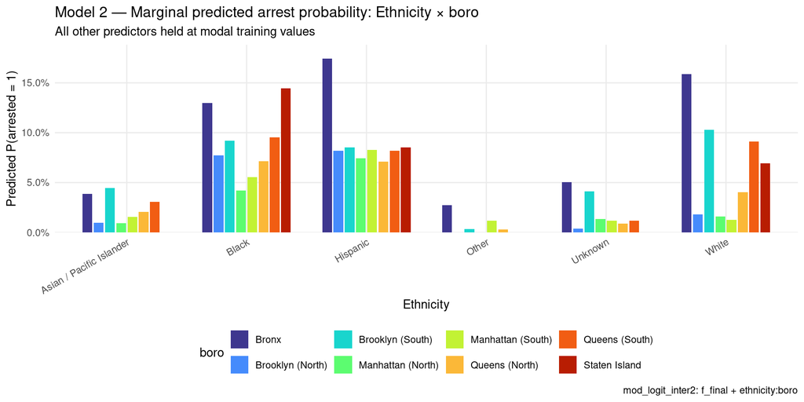

```r
vars_i2  <- setdiff(all.vars(f_inter2)[-1], c("ethnicity", use_geo))
modal_i2 <- build_modal_row(train, vars_i2)

geo_levels <- levels(train[[use_geo]])
pred_grid2 <- expand.grid(
  ethnicity = levels(train$ethnicity),
  geo__     = geo_levels,
  stringsAsFactors = FALSE
)
names(pred_grid2)[2] <- use_geo
pred_grid2[[use_geo]] <- factor(pred_grid2[[use_geo]], levels = geo_levels)

pred_grid2 <- cbind(pred_grid2, modal_i2[rep(1L, nrow(pred_grid2)), , drop = FALSE])
rownames(pred_grid2) <- NULL
pred_grid2$prob <- predict(mod_logit_inter2, newdata = pred_grid2, type = "response")

ggplot(pred_grid2, aes(x = ethnicity, y = prob, fill = .data[[use_geo]])) +
  geom_col(position = position_dodge(width = 0.75), width = 0.65) +
  scale_fill_viridis_d(option = "turbo", begin = 0.05, end = 0.92) +
  scale_y_continuous(
    labels = scales::percent_format(accuracy = 0.1),
    expand = expansion(mult = c(0, 0.08))
  ) +
  labs(
    x        = "Ethnicity",
    y        = "Predicted P(arrested = 1)",
    fill     = use_geo,
    title    = paste0("Model 2 — Marginal predicted arrest probability: Ethnicity × ", use_geo),
    subtitle = "All other predictors held at modal training values",
    caption  = paste0("mod_logit_inter2: f_final + ethnicity:", use_geo)
  ) +
  theme_minimal(base_size = 11) +
  theme(
    axis.text.x      = element_text(angle = 30, hjust = 1),
    legend.position  = "bottom",
    panel.grid.minor = element_blank()
  )
```

### Model 2 — Interaction Heatmap

The heatmap surface makes deviations from a pure additive pattern immediately visible: under pure additivity the colour gradient across each row would be identical; any row that breaks the uniform pattern reveals an interaction effect.

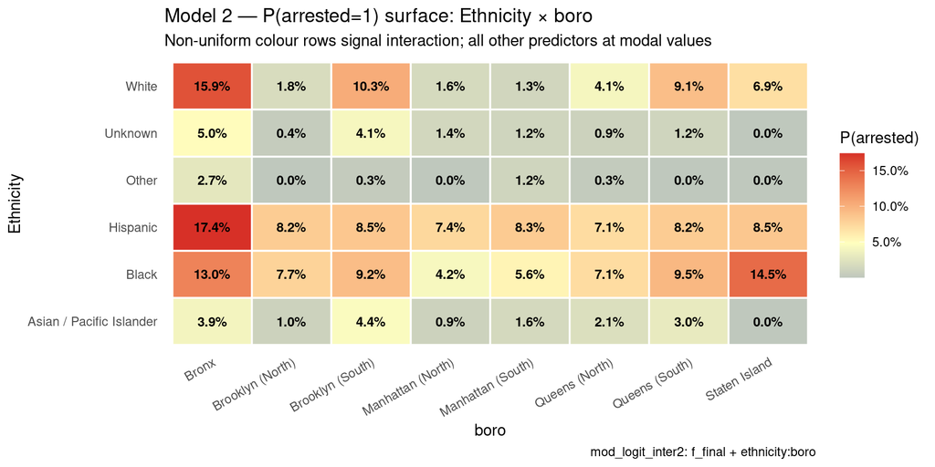

```r
ggplot(pred_grid2, aes(x = .data[[use_geo]], y = ethnicity, fill = prob)) +
  geom_tile(colour = "white", linewidth = 0.6) +
  geom_text(aes(label = scales::percent(prob, accuracy = 0.1)), size = 3.2, fontface = "bold") +
  scale_fill_gradient2(
    low      = "#4575b4",
    mid      = "#ffffbf",
    high     = "#d73027",
    midpoint = mean(pred_grid2$prob),
    labels   = scales::percent_format(accuracy = 0.1),
    name     = "P(arrested)"
  ) +
  labs(
    x        = use_geo,
    y        = "Ethnicity",
    title    = paste0("Model 2 — P(arrested=1) surface: Ethnicity × ", use_geo),
    subtitle = "Non-uniform colour rows signal interaction; all other predictors at modal values",
    caption  = paste0("mod_logit_inter2: f_final + ethnicity:", use_geo)
  ) +
  theme_minimal(base_size = 11) +
  theme(
    axis.text.x     = element_text(angle = 30, hjust = 1),
    panel.grid      = element_blank(),
    legend.position = "right"
  )
```

## Test Set Evaluation

```r
prob_inter1 <- predict(mod_logit_inter1, newdata = test, type = "response")
prob_inter2 <- predict(mod_logit_inter2, newdata = test, type = "response")

bind_rows(
  compute_metrics(test$arrested, prob_logit,   "mod_logit_best (additive)"),
  compute_metrics(test$arrested, prob_inter1,  "mod_logit_inter1  (+ethnicity:sex)"),
  compute_metrics(test$arrested, prob_inter2,  paste0("mod_logit_inter2  (+ethnicity:", use_geo, ")"))
) %>%
  kbl(
    caption   = "Interaction models vs mod_logit_best — test set metrics (Youden threshold)",
    col.names = c("Model","AUC","PR-AUC","Log-Loss","Brier",
                  "Threshold","Sensitivity","Specificity","Precision","F1","MCC","Bal. Acc.")
  ) %>%
  kable_styling(bootstrap_options = c("striped", "hover", "condensed"), full_width = TRUE)
```

Interaction models vs mod_logit_best — test set metrics (Youden threshold)

| Model | AUC | PR-AUC | Log-Loss | Brier | Threshold | Sensitivity | Specificity | Precision | F1 | MCC | Bal. Acc. |
| --- | --- | --- | --- | --- | --- | --- | --- | --- | --- | --- | --- |
| mod_logit_best (additive) | 0.6903 | 0.1249 | 0.2235 | 0.0569 | 0.0579 | 0.631 | 0.652 | 0.108 | 0.184 | 0.142 | 0.642 |
| mod_logit_inter1 (+ethnicity:sex) | 0.6912 | 0.1257 | 0.2294 | 0.0569 | 0.0537 | 0.670 | 0.616 | 0.104 | 0.180 | 0.141 | 0.643 |
| mod_logit_inter2 (+ethnicity:boro) | 0.6982 | 0.1291 | 0.2250 | 0.0568 | 0.0545 | 0.685 | 0.605 | 0.104 | 0.180 | 0.143 | 0.645 |

### Notes

- **LRT significance**: A significant LRT indicates genuine non-additivity — the combined ethnicity–sex (or ethnicity–geography) effect cannot be decomposed into independent additive contributions. This is a statistical claim, not a causal one.
- **BIC as parsimony judge**: BIC penalises model complexity more heavily than AIC (penalty $\ln n$ vs 2 per parameter). Given ~5.5% positive-class prevalence and sparse ethnicity × area cells in 2-wheel stops, BIC is the more appropriate arbiter of whether the interaction parameters are earning their keep.
- **Marginal effect plots**: Probabilities are computed at modal covariate values, not averaged over the full covariate distribution. Patterns visible here are interpretable as the interaction effect *at the modal stop profile*; marginal standardisation (average marginal effects) would give a population-averaged estimate but requires more computation.
- **Observational caution**: Disparities in predicted probabilities across demographic groups are associations in observational, self-reported data. They may reflect policing patterns, reporting artefacts, or data collection differences rather than causal differences in underlying behaviour. Comparative interpretations across ethnic groups must be made with this limitation in mind.

# iii · LDA

## Assumptions and Setup

Linear Discriminant Analysis assumes each class follows a multivariate normal distribution with a **shared** covariance matrix (i.e., homoscedastic classes). This produces a linear decision boundary, making it more constrained than QDA but with lower variance and fewer parameters to estimate. The same caveats about discrete predictors apply here as in QDA, but the shared covariance assumption makes LDA more numerically stable when the minority class is small.

- **Class imbalance**: the arrested = 1 class represents ≈ 5.5% of training observations; priors are estimated from class proportions in the training set.
- **Dimensionality**: after dummy encoding `f_final` produces 62 features. With a shared covariance matrix, the pooled estimate uses all training observations, so rank deficiency is not a concern here.

## Model Fit

```r
mod_lda <- MASS::lda(f_final, data = train)
```

## Prior Probabilities and Group Means

`MASS::lda` reports the estimated prior probabilities and within-class means of every predictor. The group means reveal which features are most discriminative under the shared-covariance assumption.

```r
cat("Prior probabilities:\n")
```

```
## Prior probabilities:
```

```r
print(mod_lda$prior)
```

```
##         0         1
## 0.9469373 0.0530627
```

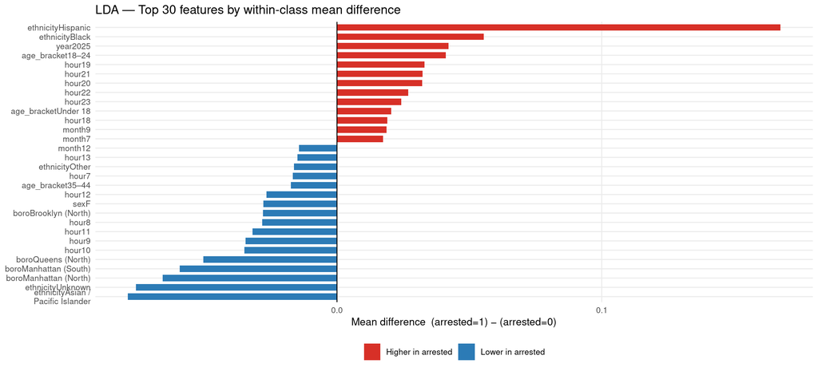

```r
means_df_lda <- as.data.frame(t(mod_lda$means)) %>%
  tibble::rownames_to_column("feature") %>%
  rename(arrested_0 = `0`, arrested_1 = `1`) %>%
  mutate(
    diff      = arrested_1 - arrested_0,
    direction = ifelse(diff > 0, "Higher in arrested", "Lower in arrested"),
    feature   = stringr::str_wrap(feature, 22)
  ) %>%
  arrange(desc(abs(diff)))

ggplot(head(means_df_lda, 30), aes(x = diff, y = reorder(feature, diff), fill = direction)) +
  geom_col(width = 0.7) +
  geom_vline(xintercept = 0, linewidth = 0.4) +
  scale_fill_manual(values = c("Higher in arrested" = "#d73027", "Lower in arrested" = "#2c7bb6")) +
  labs(
    x     = "Mean difference  (arrested=1) − (arrested=0)",
    y     = NULL,
    fill  = NULL,
    title = "LDA — Top 30 features by within-class mean difference"
  ) +
  theme_minimal(base_size = 10) +
  theme(legend.position = "bottom", panel.grid.minor = element_blank())
```

## Evaluation on the Test Set

```r
pred_lda  <- predict(mod_lda, newdata = test)
prob_lda  <- pred_lda$posterior[, "1"]
roc_lda   <- pROC::roc(test$arrested, prob_lda, quiet = TRUE)
auc_lda   <- as.numeric(pROC::auc(roc_lda))
thr_lda   <- best_thresh(roc_lda)
class_lda <- as.integer(prob_lda >= thr_lda)
met_lda   <- class_metrics(test$arrested, class_lda)

cat(sprintf(
  "AUC: %.4f  |  Threshold (Youden): %.4f\nSensitivity: %.3f  |  Specificity: %.3f  |  Balanced accuracy: %.3f\n",
  auc_lda, thr_lda, met_lda$sensitivity, met_lda$specificity, met_lda$balanced_acc
))
```

```
## AUC: 0.7011  |  Threshold (Youden): 0.0415
## Sensitivity: 0.724  |  Specificity: 0.579  |  Balanced accuracy: 0.651
```

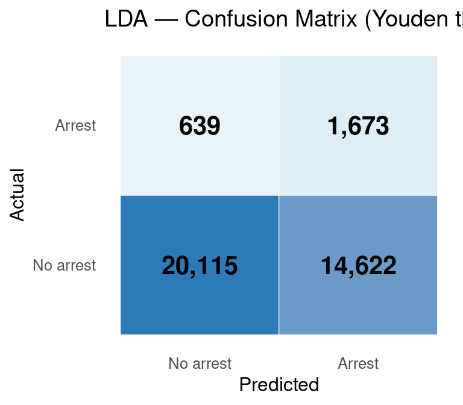

```r
plot_cm(test$arrested, class_lda, title = "LDA — Confusion Matrix (Youden threshold)")
```

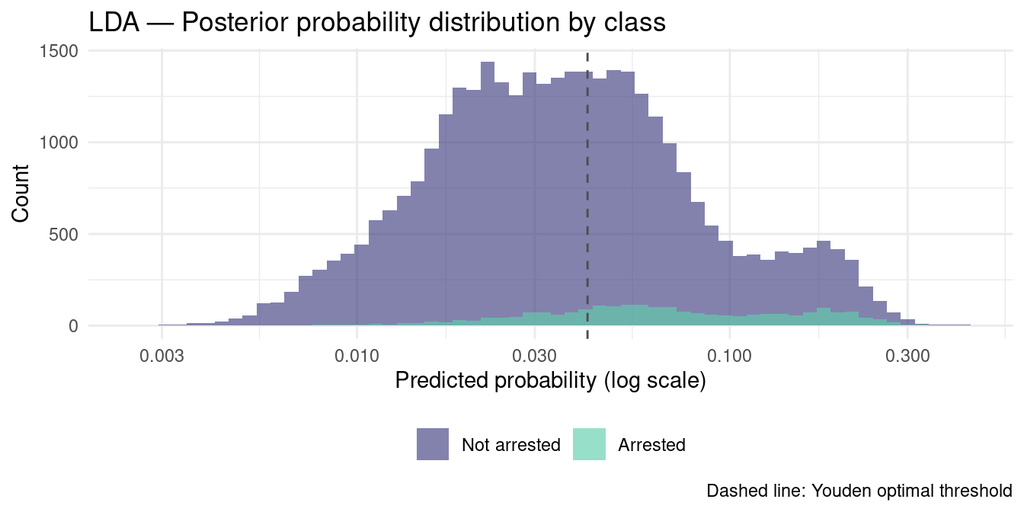

```r
tibble(prob = prob_lda, actual = factor(test$arrested, levels = c(0,1),
                                        labels = c("Not arrested","Arrested"))) %>%
  ggplot(aes(x = prob, fill = actual)) +
  geom_histogram(bins = 60, position = "identity", alpha = 0.65) +
  geom_vline(xintercept = thr_lda, linetype = "dashed", colour = "grey30") +
  scale_fill_viridis_d(option = "mako", begin = 0.3, end = 0.8) +
  scale_x_log10(labels = scales::label_number(accuracy = 0.001)) +
  labs(
    x     = "Predicted probability (log scale)",
    y     = "Count",
    fill  = NULL,
    title = "LDA — Posterior probability distribution by class",
    caption = "Dashed line: Youden optimal threshold"
  ) +
  theme_minimal(base_size = 11) +
  theme(legend.position = "bottom")
```

```r
compute_metrics(test$arrested, prob_lda, "LDA") %>%
  kbl(
    caption   = "LDA — full evaluation metrics (test set, Youden threshold)",
    col.names = c("Model","AUC","PR-AUC","Log-Loss","Brier",
                  "Threshold","Sensitivity","Specificity","Precision","F1","MCC","Bal. Acc.")
  ) %>%
  kable_styling(bootstrap_options = c("striped","condensed"), full_width = TRUE)
```

LDA — full evaluation metrics (test set, Youden threshold)

| Model | AUC | PR-AUC | Log-Loss | Brier | Threshold | Sensitivity | Specificity | Precision | F1 | MCC | Bal. Acc. |
| --- | --- | --- | --- | --- | --- | --- | --- | --- | --- | --- | --- |
| LDA | 0.7011 | 0.1263 | 0.2209 | 0.057 | 0.0415 | 0.724 | 0.579 | 0.103 | 0.18 | 0.148 | 0.651 |

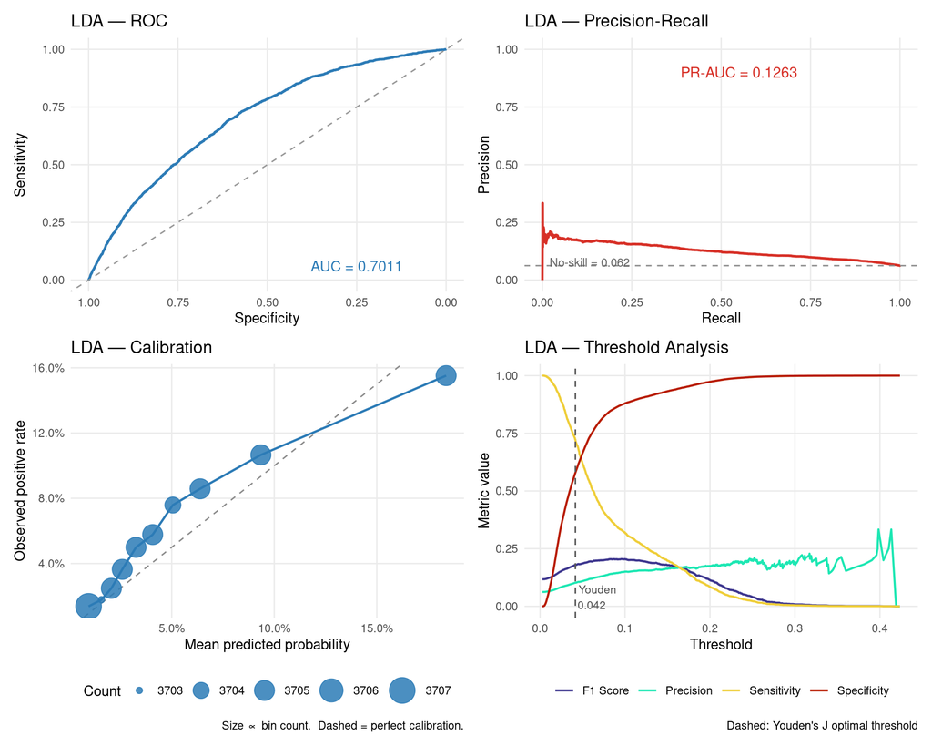

```r
eval_quad_plot(test$arrested, prob_lda, "LDA")
```

# iv · QDA

## Model Fit

```r
mod_qda <- MASS::qda(f_final, data = train)
```

## Prior Probabilities and Group Means

`MASS::qda` reports the estimated prior probabilities (class proportions in the training set) and the within-class means of every dummy variable. The group means reveal which features are most discriminative.

```r
cat("Prior probabilities:\n")
```

```
## Prior probabilities:
```

```r
print(mod_qda$prior)
```

```
##         0         1
## 0.9469373 0.0530627
```

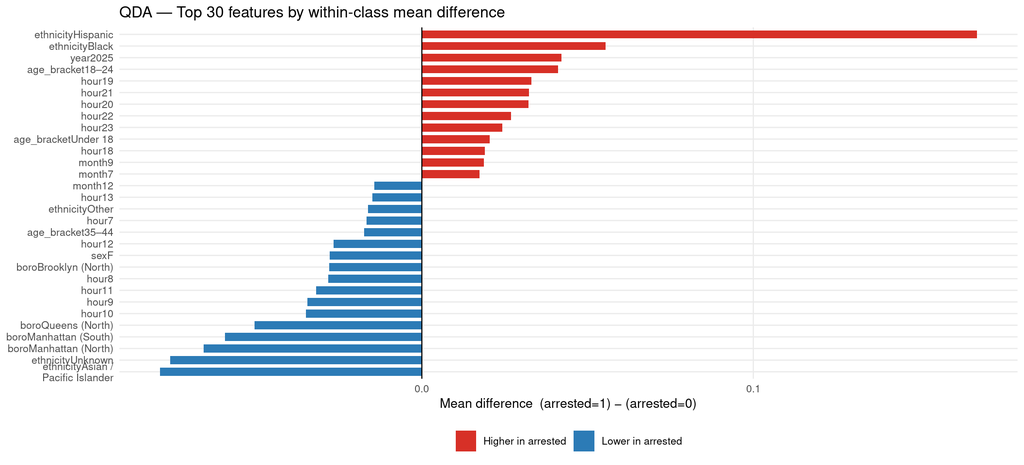

```r
means_df <- as.data.frame(t(mod_qda$means)) %>%
  tibble::rownames_to_column("feature") %>%
  rename(arrested_0 = `0`, arrested_1 = `1`) %>%
  mutate(
    diff      = arrested_1 - arrested_0,
    direction = ifelse(diff > 0, "Higher in arrested", "Lower in arrested"),
    feature   = stringr::str_wrap(feature, 22)
  ) %>%
  arrange(desc(abs(diff)))

ggplot(head(means_df, 30), aes(x = diff, y = reorder(feature, diff), fill = direction)) +
  geom_col(width = 0.7) +
  geom_vline(xintercept = 0, linewidth = 0.4) +
  scale_fill_manual(values = c("Higher in arrested" = "#d73027", "Lower in arrested" = "#2c7bb6")) +
  labs(
    x     = "Mean difference  (arrested=1) − (arrested=0)",
    y     = NULL,
    fill  = NULL,
    title = "QDA — Top 30 features by within-class mean difference"
  ) +
  theme_minimal(base_size = 10) +
  theme(legend.position = "bottom", panel.grid.minor = element_blank())
```

## Evaluation on the Test Set

```r
pred_qda  <- predict(mod_qda, newdata = test)
prob_qda  <- pred_qda$posterior[, "1"]
roc_qda   <- pROC::roc(test$arrested, prob_qda, quiet = TRUE)
auc_qda   <- as.numeric(pROC::auc(roc_qda))
thr_qda   <- best_thresh(roc_qda)
class_qda <- as.integer(prob_qda >= thr_qda)
met_qda   <- class_metrics(test$arrested, class_qda)

cat(sprintf(
  "AUC: %.4f  |  Threshold (Youden): %.4f\nSensitivity: %.3f  |  Specificity: %.3f  |  Balanced accuracy: %.3f\n",
  auc_qda, thr_qda, met_qda$sensitivity, met_qda$specificity, met_qda$balanced_acc
))
```

```
## AUC: 0.6698  |  Threshold (Youden): 0.9966
## Sensitivity: 0.609  |  Specificity: 0.671  |  Balanced accuracy: 0.640
```

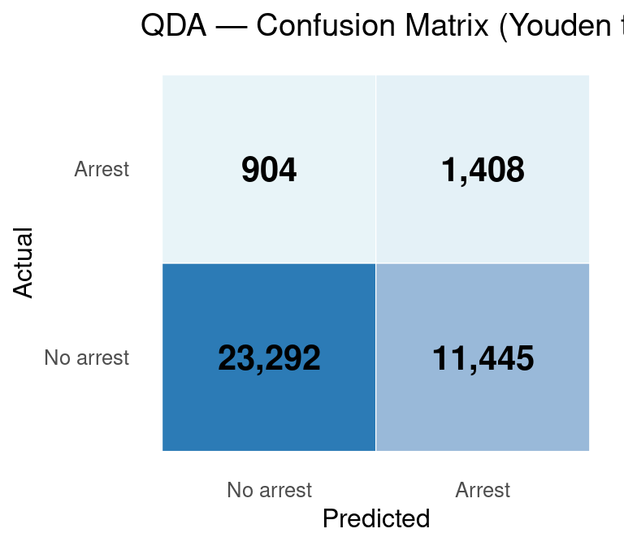

```r
plot_cm(test$arrested, class_qda, title = "QDA — Confusion Matrix (Youden threshold)")
```

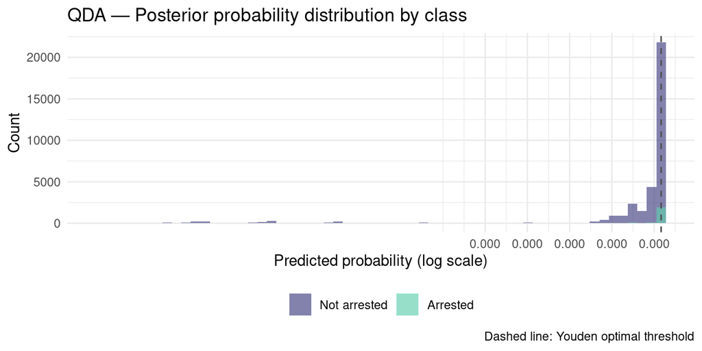

```r
tibble(prob = prob_qda, actual = factor(test$arrested, levels = c(0,1),
                                        labels = c("Not arrested","Arrested"))) %>%
  ggplot(aes(x = prob, fill = actual)) +
  geom_histogram(bins = 60, position = "identity", alpha = 0.65) +
  geom_vline(xintercept = thr_qda, linetype = "dashed", colour = "grey30") +
  scale_fill_viridis_d(option = "mako", begin = 0.3, end = 0.8) +
  scale_x_log10(labels = scales::label_number(accuracy = 0.001)) +
  labs(
    x     = "Predicted probability (log scale)",
    y     = "Count",
    fill  = NULL,
    title = "QDA — Posterior probability distribution by class",
    caption = "Dashed line: Youden optimal threshold"
  ) +
  theme_minimal(base_size = 11) +
  theme(legend.position = "bottom")
```

```r
compute_metrics(test$arrested, prob_qda, "QDA") %>%
  kbl(
    caption   = "QDA — full evaluation metrics (test set, Youden threshold)",
    col.names = c("Model","AUC","PR-AUC","Log-Loss","Brier",
                  "Threshold","Sensitivity","Specificity","Precision","F1","MCC","Bal. Acc.")
  ) %>%
  kable_styling(bootstrap_options = c("striped","condensed"), full_width = TRUE)
```

QDA — full evaluation metrics (test set, Youden threshold)

| Model | AUC | PR-AUC | Log-Loss | Brier | Threshold | Sensitivity | Specificity | Precision | F1 | MCC | Bal. Acc. |
| --- | --- | --- | --- | --- | --- | --- | --- | --- | --- | --- | --- |
| QDA | 0.6698 | 0.1099 | 4.2487 | 0.4807 | 0.9966 | 0.609 | 0.671 | 0.11 | 0.186 | 0.142 | 0.64 |

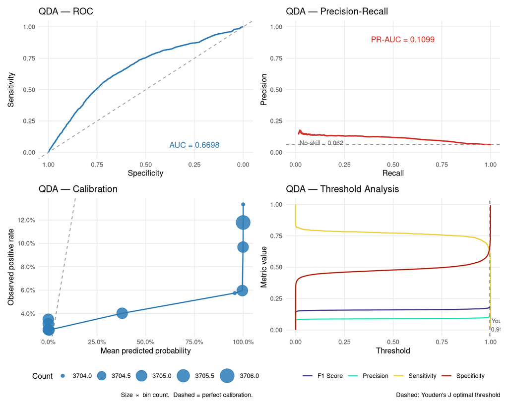

```r
eval_quad_plot(test$arrested, prob_qda, "QDA")
```

# v · Naive Bayes

## Assumptions and Setup

Naive Bayes assumes conditional independence of all features given the class label. For purely categorical predictors it estimates a frequency table per feature–class combination (with optional Laplace smoothing to prevent zero-probability cells). The independence assumption is almost certainly violated—time of day, area, and demographic features are correlated—but Naive Bayes often produces competitive probabilistic rankings even when it is. The Laplace smoothing parameter $k$ is the only tuning knob; it is selected by 10-fold cross-validated AUC on the training set using the same folds as section ii.

## Laplace Smoothing Tuning

```r
laplace_grid <- c(0, 0.5, 1, 2, 5, 10)

nb_cv_auc <- function(k, data, folds_vec, formula) {
  n_folds  <- max(folds_vec)
  auc_vals <- numeric(n_folds)
  for (i in seq_len(n_folds)) {
    tr  <- data[folds_vec != i, ]
    te  <- data[folds_vec == i, ]
    fit <- e1071::naiveBayes(formula, data = tr, laplace = k)
    # posterior: columns named after class levels; column 2 = P(arrested=1)
    prob <- predict(fit, newdata = te, type = "raw")[, 2]
    auc_vals[i] <- tryCatch(
      as.numeric(pROC::auc(te$arrested, prob, quiet = TRUE)),
      error = function(e) NA_real_
    )
  }
  mean(auc_vals, na.rm = TRUE)
}

nb_aucs <- sapply(
  laplace_grid, nb_cv_auc,
  data = train, folds_vec = cv_folds,
  formula = f_final
  )

best_laplace <- laplace_grid[which.max(nb_aucs)]

cat("Best Laplace k:", best_laplace, " | CV AUC:", round(max(nb_aucs), 4), "\n")
```

```
## Best Laplace k: 5  | CV AUC: 0.7383
```

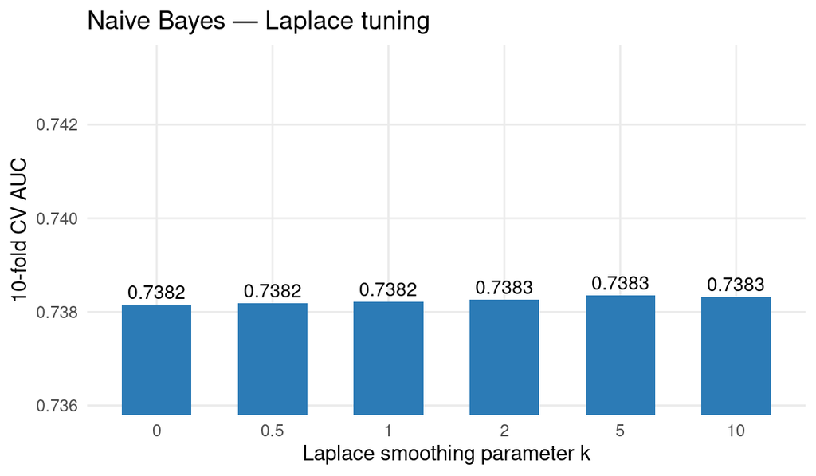

```r
tibble(k = laplace_grid, CV_AUC = nb_aucs) %>%
  ggplot(aes(x = factor(k), y = CV_AUC)) +
  geom_col(fill = "#2c7bb6", width = 0.6) +
  geom_text(aes(label = round(CV_AUC, 4)), vjust = -0.4, size = 3.5) +
  labs(
    x     = "Laplace smoothing parameter k",
    y     = "10-fold CV AUC",
    title = "Naive Bayes — Laplace tuning"
  ) +
  coord_cartesian(ylim = c(min(nb_aucs) - 0.002, max(nb_aucs) + 0.005)) +
  theme_minimal(base_size = 11) +
  theme(panel.grid.minor = element_blank())
```

## Model Fit

```r
mod_nb <- e1071::naiveBayes(f_final, data = train, laplace = best_laplace)
```

## Conditional Probability Tables — Key Predictors

Each table entry shows $\hat{P}(\text{feature level} \mid \text{class})$. Features whose conditional distributions differ most between classes are the strongest discriminators under the independence assumption.

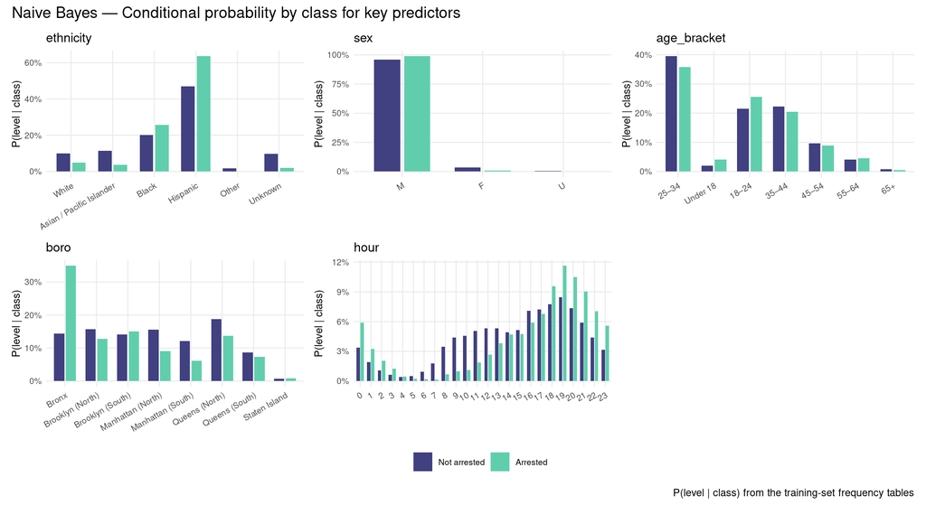

```r
# Extract tables for a selected set of substantively interesting predictors
plot_nb_feature <- function(feature_name, mod) {
  tbl <- mod$tables[[feature_name]]
  as.data.frame(tbl) %>%
    rename(level = 2, class = 1, prob = Freq) %>%
    mutate(class = factor(class, labels = c("Not arrested", "Arrested"))) %>%
    ggplot(aes(x = level, y = prob, fill = class)) +
    geom_col(position = position_dodge(width = 0.75), width = 0.65) +
    scale_fill_viridis_d(option = "mako", begin = 0.3, end = 0.8) +
    scale_y_continuous(labels = scales::percent_format(accuracy = 1)) +
    labs(x = NULL, y = "P(level | class)", title = feature_name, fill = NULL) +
    theme_minimal(base_size = 9) +
    theme(
      axis.text.x    = element_text(angle = 30, hjust = 1),
      legend.position = "bottom",
      panel.grid.minor = element_blank()
    )
}

key_preds <- intersect(
  c("ethnicity", "sex", "age_bracket", use_geo, use_time),
  names(mod_nb$tables)
)

plots_nb <- lapply(key_preds, plot_nb_feature, mod = mod_nb)
patchwork::wrap_plots(plots_nb, ncol = 3) +
  patchwork::plot_annotation(
    title   = "Naive Bayes — Conditional probability by class for key predictors",
    caption = "P(level | class) from the training-set frequency tables"
  ) +
  patchwork::plot_layout(guides = "collect") &
  theme(legend.position = "bottom")
```

## Evaluation on the Test Set

```r
prob_nb  <- predict(mod_nb, newdata = test, type = "raw")[, 2]
roc_nb   <- pROC::roc(test$arrested, prob_nb, quiet = TRUE)
auc_nb   <- as.numeric(pROC::auc(roc_nb))
thr_nb   <- best_thresh(roc_nb)
class_nb <- as.integer(prob_nb >= thr_nb)
met_nb   <- class_metrics(test$arrested, class_nb)

cat(sprintf(
  "AUC: %.4f  |  Threshold (Youden): %.4f\nSensitivity: %.3f  |  Specificity: %.3f  |  Balanced accuracy: %.3f\n",
  auc_nb, thr_nb, met_nb$sensitivity, met_nb$specificity, met_nb$balanced_acc
))
```

```
## AUC: 0.6868  |  Threshold (Youden): 0.0401
## Sensitivity: 0.735  |  Specificity: 0.538  |  Balanced accuracy: 0.636
```

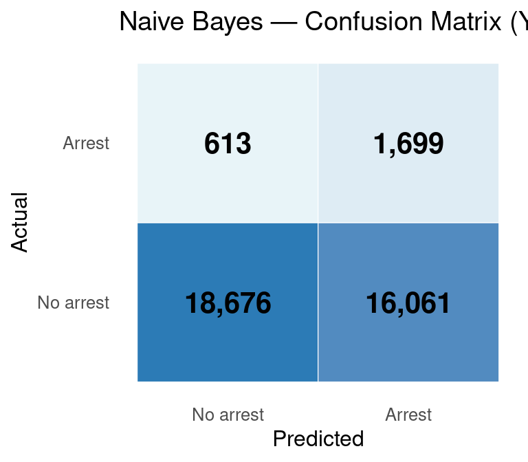

```r
plot_cm(test$arrested, class_nb, title = "Naive Bayes — Confusion Matrix (Youden threshold)")
```

```r
compute_metrics(test$arrested, prob_nb, "Naive Bayes") %>%
  kbl(
    caption   = "Naive Bayes — full evaluation metrics (test set, Youden threshold)",
    col.names = c("Model","AUC","PR-AUC","Log-Loss","Brier",
                  "Threshold","Sensitivity","Specificity","Precision","F1","MCC","Bal. Acc.")
  ) %>%
  kable_styling(bootstrap_options = c("striped","condensed"), full_width = TRUE)
```

Naive Bayes — full evaluation metrics (test set, Youden threshold)

| Model | AUC | PR-AUC | Log-Loss | Brier | Threshold | Sensitivity | Specificity | Precision | F1 | MCC | Bal. Acc. |
| --- | --- | --- | --- | --- | --- | --- | --- | --- | --- | --- | --- |
| Naive Bayes | 0.6868 | 0.1196 | 0.227 | 0.0576 | 0.0401 | 0.735 | 0.538 | 0.096 | 0.169 | 0.132 | 0.636 |

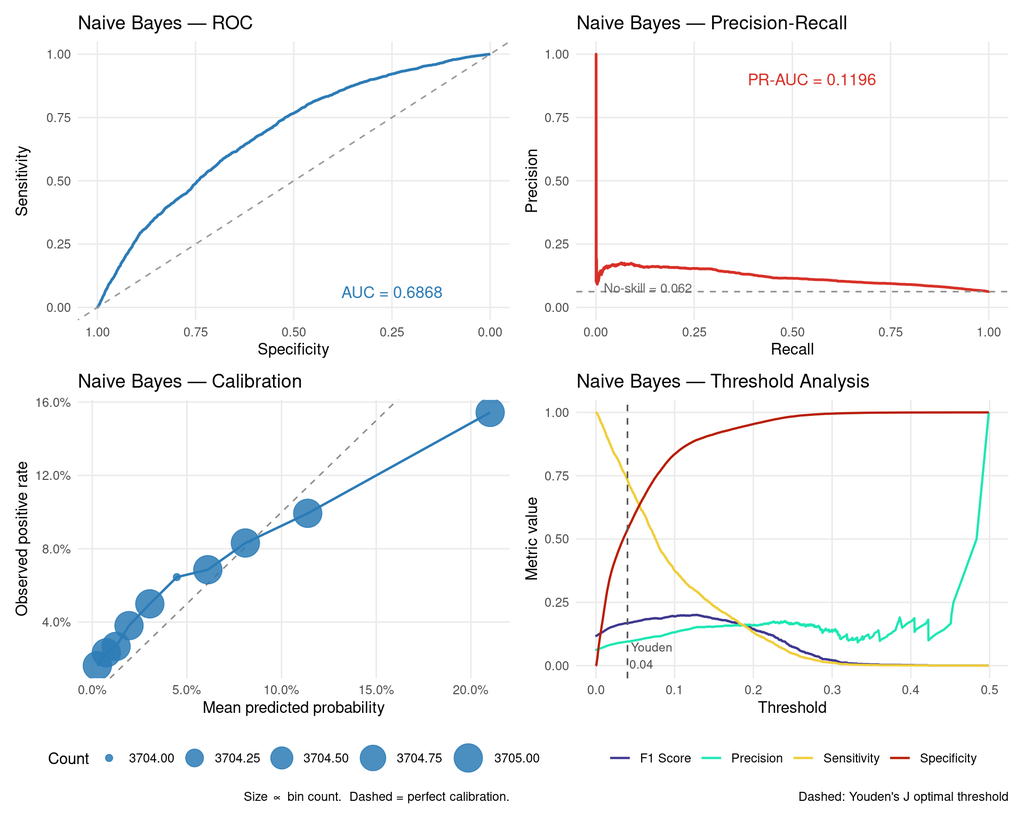

```r
eval_quad_plot(test$arrested, prob_nb, "Naive Bayes")
```

# vi · Ridge

## Cross-Validated Lambda

```r
cv_ridge <- cv.glmnet(
  X_train, y_train,
  family       = "binomial",
  alpha        = 0,
  foldid       = cv_folds,
  type.measure = "auc"
)

cat(sprintf(
  "λ.min  = %.6f  (CV AUC = %.4f)\nλ.1se  = %.6f  (CV AUC = %.4f)\n",
  cv_ridge$lambda.min, max(cv_ridge$cvm),
  cv_ridge$lambda.1se,
  cv_ridge$cvm[cv_ridge$lambda == cv_ridge$lambda.1se]
))
```

```
## λ.min  = 0.001684  (CV AUC = 0.7409)
## λ.1se  = 0.008188  (CV AUC = 0.7386)
```

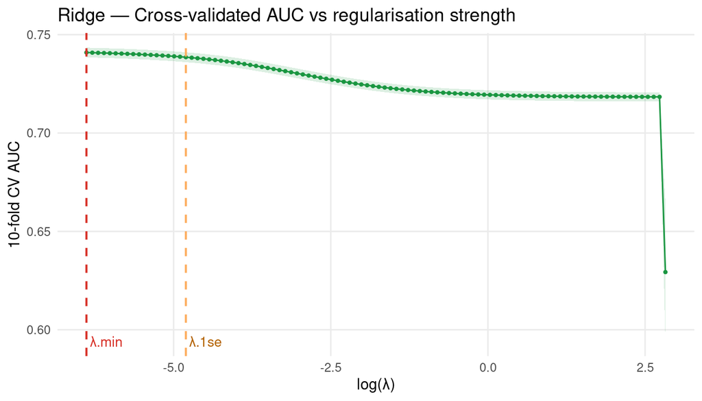

```r
cv_df_ridge <- tibble(
  log_lambda = log(cv_ridge$lambda),
  cvm        = cv_ridge$cvm,
  cvup       = cv_ridge$cvup,
  cvlo       = cv_ridge$cvlo
)

ggplot(cv_df_ridge, aes(x = log_lambda, y = cvm)) +
  geom_ribbon(aes(ymin = cvlo, ymax = cvup), alpha = 0.15, fill = "#1a9641") +
  geom_line(colour = "#1a9641") +
  geom_point(size = 0.8, colour = "#1a9641") +
  geom_vline(xintercept = log(cv_ridge$lambda.min), linetype = "dashed",
             colour = "#d73027", linewidth = 0.7) +
  geom_vline(xintercept = log(cv_ridge$lambda.1se), linetype = "dashed",
             colour = "#fdae61", linewidth = 0.7) +
  annotate("text", x = log(cv_ridge$lambda.min), y = min(cv_df_ridge$cvlo),
           label = "λ.min", colour = "#d73027", hjust = -0.1, size = 3.5) +
  annotate("text", x = log(cv_ridge$lambda.1se), y = min(cv_df_ridge$cvlo),
           label = "λ.1se", colour = "#b36200", hjust = -0.1, size = 3.5) +
  labs(
    x     = "log(λ)",
    y     = "10-fold CV AUC",
    title = "Ridge — Cross-validated AUC vs regularisation strength"
  ) +
  theme_minimal(base_size = 11) +
  theme(panel.grid.minor = element_blank())
```

## Top Coefficients at λ.min

Unlike LASSO, Ridge retains all predictors. We display the top 30 by absolute coefficient magnitude.

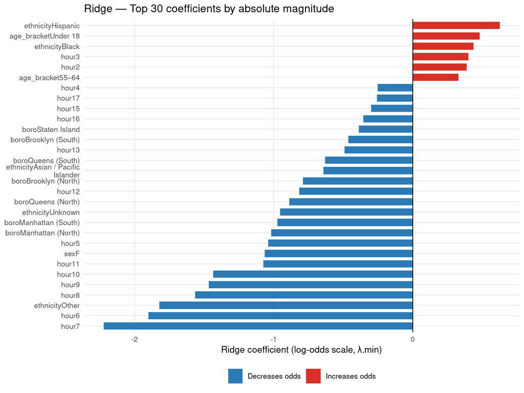

```r
cf_ridge <- coef(cv_ridge, s = "lambda.min")
coef_ridge_df <- tibble(
  feature  = rownames(cf_ridge)[-1],
  estimate = as.numeric(cf_ridge[-1])
) %>%
  arrange(desc(abs(estimate))) %>%
  head(30) %>%
  mutate(
    direction = ifelse(estimate > 0, "Increases odds", "Decreases odds"),
    feature   = stringr::str_wrap(feature, 30)
  )

ggplot(coef_ridge_df, aes(x = estimate, y = reorder(feature, estimate), fill = direction)) +
  geom_col(width = 0.7) +
  geom_vline(xintercept = 0, linewidth = 0.4) +
  scale_fill_manual(values = c("Increases odds" = "#d73027", "Decreases odds" = "#2c7bb6")) +
  labs(
    x     = "Ridge coefficient (log-odds scale, λ.min)",
    y     = NULL,
    fill  = NULL,
    title = "Ridge — Top 30 coefficients by absolute magnitude"
  ) +
  theme_minimal(base_size = 10) +
  theme(legend.position = "bottom", panel.grid.minor = element_blank())
```

## Evaluation on the Test Set

```r
prob_ridge <- as.numeric(predict(cv_ridge, newx = X_test, s = "lambda.min", type = "response"))
roc_ridge  <- pROC::roc(y_test, prob_ridge, quiet = TRUE)
auc_ridge  <- as.numeric(pROC::auc(roc_ridge))
thr_ridge  <- best_thresh(roc_ridge)
class_ridge <- as.integer(prob_ridge >= thr_ridge)
met_ridge   <- class_metrics(y_test, class_ridge)

cat(sprintf(
  "AUC: %.4f  |  Threshold (Youden): %.4f\nSensitivity: %.3f  |  Specificity: %.3f  |  Balanced accuracy: %.3f\n",
  auc_ridge, thr_ridge, met_ridge$sensitivity, met_ridge$specificity, met_ridge$balanced_acc
))
```

```
## AUC: 0.6900  |  Threshold (Youden): 0.0573
## Sensitivity: 0.644  |  Specificity: 0.638  |  Balanced accuracy: 0.641
```

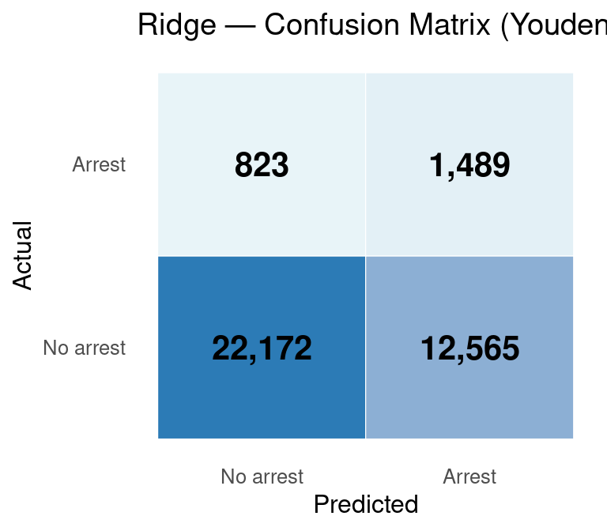

```r
plot_cm(y_test, class_ridge, title = "Ridge — Confusion Matrix (Youden threshold)")
```

```r
compute_metrics(y_test, prob_ridge, "Ridge (λ.min)") %>%
  kbl(
    caption   = "Ridge — full evaluation metrics (test set, Youden threshold)",
    col.names = c("Model","AUC","PR-AUC","Log-Loss","Brier",
                  "Threshold","Sensitivity","Specificity","Precision","F1","MCC","Bal. Acc.")
  ) %>%
  kable_styling(bootstrap_options = c("striped","condensed"), full_width = TRUE)
```

Ridge — full evaluation metrics (test set, Youden threshold)

| Model | AUC | PR-AUC | Log-Loss | Brier | Threshold | Sensitivity | Specificity | Precision | F1 | MCC | Bal. Acc. |
| --- | --- | --- | --- | --- | --- | --- | --- | --- | --- | --- | --- |
| Ridge (λ.min) | 0.69 | 0.1246 | 0.2223 | 0.0569 | 0.0573 | 0.644 | 0.638 | 0.106 | 0.182 | 0.141 | 0.641 |

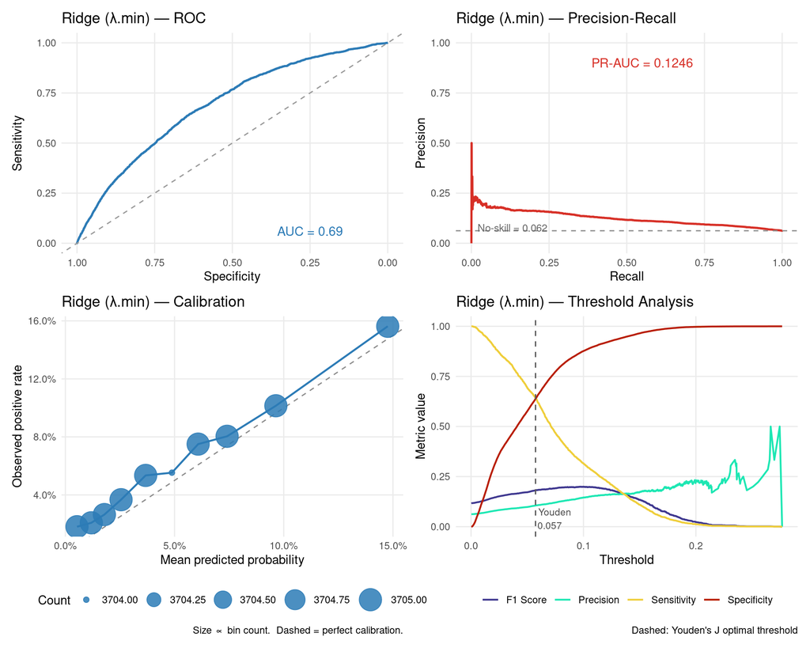

```r
eval_quad_plot(y_test, prob_ridge, "Ridge (λ.min)")
```

# vii · LASSO

## Setup

Logistic LASSO penalises the sum of absolute coefficient values ($\ell_1$ penalty), which shrinks small effects to exactly zero and performs implicit variable selection. We use the `glmnet` package with `family = "binomial"` and `alpha = 1` (pure LASSO, no ridge component). All categorical predictors are dummy-encoded via `model.matrix`; the intercept column is excluded because `glmnet` adds its own unpenalised intercept. The penalty parameter $\lambda$ is selected by 10-fold cross-validated AUC on the training set.

## Model Matrix

```r
X_train <- model.matrix(f_final, data = train)[, -1]   # drop intercept column
X_test  <- model.matrix(f_final, data = test)[, -1]
y_train <- train$arrested
y_test  <- test$arrested

cat("Training matrix:", nrow(X_train), "×", ncol(X_train), "\n")
```

```
## Training matrix: 143566 × 62
```

```r
cat("Test matrix    :", nrow(X_test),  "×", ncol(X_test),  "\n")
```

```
## Test matrix    : 37049 × 62
```

## Cross-Validated Lambda

We optimise $\lambda$ by maximising cross-validated AUC (`type.measure = "auc"`), which is the appropriate metric for an imbalanced binary outcome.

```r
set.seed(2026)
cv_lasso <- cv.glmnet(
  X_train, y_train,
  family       = "binomial",
  alpha        = 1,
  nfolds       = 10,
  type.measure = "auc"
)

cat(sprintf(
  "λ.min  = %.6f  (CV AUC = %.4f)\nλ.1se  = %.6f  (CV AUC = %.4f)\n",
  cv_lasso$lambda.min, max(cv_lasso$cvm),
  cv_lasso$lambda.1se,
  cv_lasso$cvm[cv_lasso$lambda == cv_lasso$lambda.1se]
))
```

```
## λ.min  = 0.000063  (CV AUC = 0.7414)
## λ.1se  = 0.000782  (CV AUC = 0.7391)
```

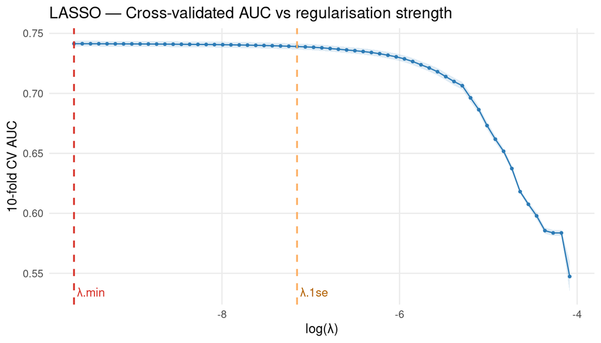

```r
# Replicate the cv.glmnet plot in ggplot2
cv_df <- tibble(
  log_lambda = log(cv_lasso$lambda),
  cvm        = cv_lasso$cvm,
  cvup       = cv_lasso$cvup,
  cvlo       = cv_lasso$cvlo,
  nzero      = cv_lasso$nzero
)

ggplot(cv_df, aes(x = log_lambda, y = cvm)) +
  geom_ribbon(aes(ymin = cvlo, ymax = cvup), alpha = 0.15, fill = "#2c7bb6") +
  geom_line(colour = "#2c7bb6") +
  geom_point(size = 0.8, colour = "#2c7bb6") +
  geom_vline(xintercept = log(cv_lasso$lambda.min), linetype = "dashed",
             colour = "#d73027", linewidth = 0.7) +
  geom_vline(xintercept = log(cv_lasso$lambda.1se), linetype = "dashed",
             colour = "#fdae61", linewidth = 0.7) +
  annotate("text", x = log(cv_lasso$lambda.min), y = min(cv_df$cvlo),
           label = "λ.min", colour = "#d73027", hjust = -0.1, size = 3.5) +
  annotate("text", x = log(cv_lasso$lambda.1se), y = min(cv_df$cvlo),
           label = "λ.1se", colour = "#b36200", hjust = -0.1, size = 3.5) +
  labs(
    x     = "log(λ)",
    y     = "10-fold CV AUC",
    title = "LASSO — Cross-validated AUC vs regularisation strength"
  ) +
  theme_minimal(base_size = 11) +
  theme(panel.grid.minor = element_blank())
```

## Coefficient Path

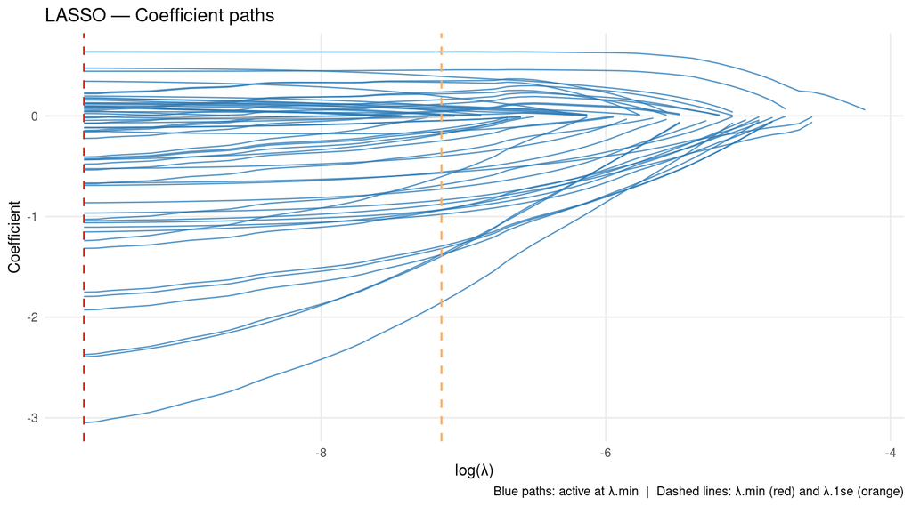

```r
# Tidy the full coefficient path
coef_path <- as.matrix(coef(cv_lasso$glmnet.fit))   # (p+1) × n_lambda
lambdas   <- cv_lasso$glmnet.fit$lambda

path_df <- as.data.frame(t(coef_path[-1, ])) %>%   # drop intercept row
  mutate(log_lambda = log(lambdas)) %>%
  pivot_longer(-log_lambda, names_to = "feature", values_to = "coef") %>%
  filter(coef != 0)

# Only label non-zero at lambda.min for clarity
active_min <- names(which(coef(cv_lasso, s = "lambda.min")[-1, 1] != 0))

ggplot(path_df, aes(x = log_lambda, y = coef, group = feature,
                    colour = feature %in% active_min)) +
  geom_line(linewidth = 0.45, alpha = 0.8) +
  geom_vline(xintercept = log(cv_lasso$lambda.min), linetype = "dashed",
             colour = "#d73027", linewidth = 0.7) +
  geom_vline(xintercept = log(cv_lasso$lambda.1se), linetype = "dashed",
             colour = "#fdae61", linewidth = 0.7) +
  scale_colour_manual(values = c("TRUE" = "#2c7bb6", "FALSE" = "grey70"),
                      guide  = "none") +
  labs(
    x       = "log(λ)",
    y       = "Coefficient",
    title   = "LASSO — Coefficient paths",
    caption = "Blue paths: active at λ.min  |  Dashed lines: λ.min (red) and λ.1se (orange)"
  ) +
  theme_minimal(base_size = 11) +
  theme(panel.grid.minor = element_blank())
```

## Selected Coefficients

```r
extract_coefs <- function(cv_fit, s_name) {
  cf <- coef(cv_fit, s = s_name)
  tibble(
    feature  = rownames(cf)[-1],
    estimate = as.numeric(cf[-1])
  ) %>%
    filter(estimate != 0) %>%
    arrange(desc(abs(estimate))) %>%
    mutate(OR = round(exp(estimate), 3), estimate = round(estimate, 4))
}

coef_min <- extract_coefs(cv_lasso, "lambda.min")
coef_1se <- extract_coefs(cv_lasso, "lambda.1se")

cat("Non-zero coefficients at λ.min:", nrow(coef_min), "\n")
```

```
## Non-zero coefficients at λ.min: 59
```

```r
cat("Non-zero coefficients at λ.1se:", nrow(coef_1se), "\n")
```

```
## Non-zero coefficients at λ.1se: 49
```

```r
coef_min %>%
  kbl(
    caption   = "LASSO coefficients at λ.min (sorted by |estimate|)",
    col.names = c("Feature", "Log-odds", "Odds Ratio")
  ) %>%
  kable_styling(bootstrap_options = c("striped", "condensed"), full_width = FALSE)
```

LASSO coefficients at λ.min (sorted by |estimate|)

| Feature | Log-odds | Odds Ratio |
| --- | --- | --- |
| hour7 | -3.0495 | 0.047 |
| ethnicityOther | -2.3936 | 0.091 |
| hour6 | -2.3727 | 0.093 |
| hour8 | -1.9282 | 0.145 |
| hour9 | -1.7947 | 0.166 |
| hour10 | -1.7507 | 0.174 |
| hour11 | -1.3159 | 0.268 |
| hour5 | -1.2399 | 0.289 |
| sexF | -1.1525 | 0.316 |
| boroManhattan (North) | -1.1055 | 0.331 |
| boroManhattan (South) | -1.0614 | 0.346 |
| ethnicityUnknown | -1.0409 | 0.353 |
| hour12 | -1.0273 | 0.358 |
| boroQueens (North) | -0.9647 | 0.381 |
| boroBrooklyn (North) | -0.8622 | 0.422 |
| boroQueens (South) | -0.6903 | 0.501 |
| hour13 | -0.6744 | 0.509 |
| ethnicityAsian / Pacific Islander | -0.6660 | 0.514 |
| ethnicityHispanic | 0.6368 | 1.890 |
| hour16 | -0.5362 | 0.585 |
| boroBrooklyn (South) | -0.5237 | 0.592 |
| hour15 | -0.4777 | 0.620 |
| age_bracketUnder 18 | 0.4755 | 1.609 |
| ethnicityBlack | 0.4438 | 1.559 |
| hour17 | -0.4349 | 0.647 |
| boroStaten Island | -0.4342 | 0.648 |
| hour14 | -0.4239 | 0.655 |
| hour4 | -0.4072 | 0.666 |
| age_bracket55–64 | 0.3451 | 1.412 |
| hour3 | 0.2288 | 1.257 |
| hour18 | -0.2222 | 0.801 |
| hour2 | 0.2200 | 1.246 |
| year2025 | 0.1973 | 1.218 |
| month9 | 0.1808 | 1.198 |
| age_bracket45–54 | 0.1715 | 1.187 |
| month7 | 0.1586 | 1.172 |
| hour19 | -0.1569 | 0.855 |
| month12 | -0.1523 | 0.859 |
| hour20 | -0.1429 | 0.867 |
| weekdayTuesday | 0.1309 | 1.140 |
| age_bracket18–24 | 0.1214 | 1.129 |
| year2024 | 0.1197 | 1.127 |
| weekdaySunday | -0.1183 | 0.888 |
| weekdayFriday | -0.1141 | 0.892 |
| age_bracket35–44 | 0.1018 | 1.107 |
| month10 | 0.0944 | 1.099 |
| month4 | 0.0932 | 1.098 |
| month5 | 0.0916 | 1.096 |
| month6 | 0.0868 | 1.091 |
| hour21 | -0.0747 | 0.928 |
| weekdaySaturday | -0.0700 | 0.932 |
| hour1 | 0.0700 | 1.072 |
| hour23 | 0.0542 | 1.056 |
| month3 | 0.0461 | 1.047 |
| age_bracket65+ | -0.0444 | 0.957 |
| weekdayWednesday | 0.0418 | 1.043 |
| month11 | 0.0243 | 1.025 |
| hour22 | -0.0199 | 0.980 |
| month2 | -0.0099 | 0.990 |

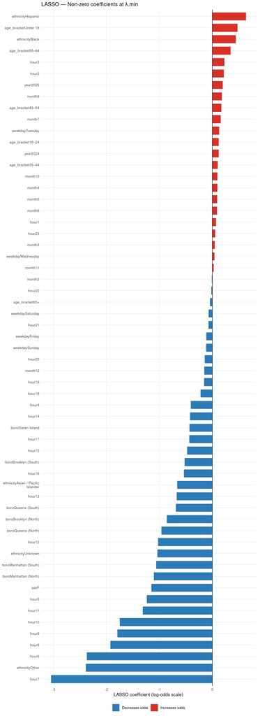

```r
coef_min %>%
  mutate(
    direction = ifelse(estimate > 0, "Increases odds", "Decreases odds"),
    feature   = stringr::str_wrap(feature, 30)
  ) %>%
  ggplot(aes(x = estimate, y = reorder(feature, estimate), fill = direction)) +
  geom_col(width = 0.7) +
  geom_vline(xintercept = 0, linewidth = 0.4) +
  scale_fill_manual(values = c("Increases odds" = "#d73027", "Decreases odds" = "#2c7bb6")) +
  labs(
    x     = "LASSO coefficient (log-odds scale)",
    y     = NULL,
    fill  = NULL,
    title = "LASSO — Non-zero coefficients at λ.min"
  ) +
  theme_minimal(base_size = 10) +
  theme(legend.position = "bottom", panel.grid.minor = element_blank())
```

## Evaluation on the Test Set

```r
prob_lasso_min <- as.numeric(predict(cv_lasso, newx = X_test, s = "lambda.min", type = "response"))
prob_lasso_1se <- as.numeric(predict(cv_lasso, newx = X_test, s = "lambda.1se", type = "response"))

roc_lasso_min <- pROC::roc(y_test, prob_lasso_min, quiet = TRUE)
roc_lasso_1se <- pROC::roc(y_test, prob_lasso_1se, quiet = TRUE)
auc_lasso_min <- as.numeric(pROC::auc(roc_lasso_min))
auc_lasso_1se <- as.numeric(pROC::auc(roc_lasso_1se))

thr_lasso_min  <- best_thresh(roc_lasso_min)
class_lasso_min <- as.integer(prob_lasso_min >= thr_lasso_min)
met_lasso_min   <- class_metrics(y_test, class_lasso_min)

cat(sprintf(
  "λ.min — AUC: %.4f  |  Threshold: %.4f  |  Sens: %.3f  |  Spec: %.3f  |  Bal.Acc: %.3f\n",
  auc_lasso_min, thr_lasso_min,
  met_lasso_min$sensitivity, met_lasso_min$specificity, met_lasso_min$balanced_acc
))
```

```
## λ.min — AUC: 0.6902  |  Threshold: 0.0547  |  Sens: 0.662  |  Spec: 0.622  |  Bal.Acc: 0.642
```

```r
thr_lasso_1se   <- best_thresh(roc_lasso_1se)
class_lasso_1se <- as.integer(prob_lasso_1se >= thr_lasso_1se)
met_lasso_1se   <- class_metrics(y_test, class_lasso_1se)

cat(sprintf(
  "λ.1se — AUC: %.4f  |  Threshold: %.4f  |  Sens: %.3f  |  Spec: %.3f  |  Bal.Acc: %.3f\n",
  auc_lasso_1se, thr_lasso_1se,
  met_lasso_1se$sensitivity, met_lasso_1se$specificity, met_lasso_1se$balanced_acc
))
```

```
## λ.1se — AUC: 0.6896  |  Threshold: 0.0573  |  Sens: 0.654  |  Spec: 0.627  |  Bal.Acc: 0.640
```

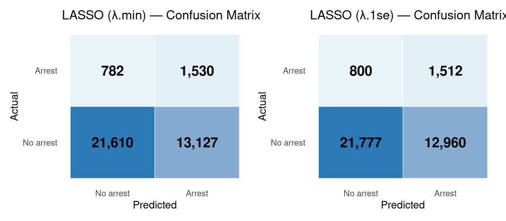

```r
p_cm_min <- plot_cm(y_test, class_lasso_min, "LASSO (λ.min) — Confusion Matrix")
p_cm_1se <- plot_cm(y_test, class_lasso_1se, "LASSO (λ.1se) — Confusion Matrix")
p_cm_min | p_cm_1se
```

```r
bind_rows(
  compute_metrics(y_test, prob_lasso_min, "LASSO λ.min"),
  compute_metrics(y_test, prob_lasso_1se, "LASSO λ.1se")
) %>%
  kbl(
    caption   = "LASSO — full evaluation metrics (test set, Youden threshold)",
    col.names = c("Model","AUC","PR-AUC","Log-Loss","Brier",
                  "Threshold","Sensitivity","Specificity","Precision","F1","MCC","Bal. Acc.")
  ) %>%
  kable_styling(bootstrap_options = c("striped","condensed"), full_width = TRUE)
```

LASSO — full evaluation metrics (test set, Youden threshold)

| Model | AUC | PR-AUC | Log-Loss | Brier | Threshold | Sensitivity | Specificity | Precision | F1 | MCC | Bal. Acc. |
| --- | --- | --- | --- | --- | --- | --- | --- | --- | --- | --- | --- |
| LASSO λ.min | 0.6902 | 0.1250 | 0.2232 | 0.0569 | 0.0547 | 0.662 | 0.622 | 0.104 | 0.18 | 0.140 | 0.642 |
| LASSO λ.1se | 0.6896 | 0.1232 | 0.2217 | 0.0569 | 0.0573 | 0.654 | 0.627 | 0.104 | 0.18 | 0.139 | 0.640 |

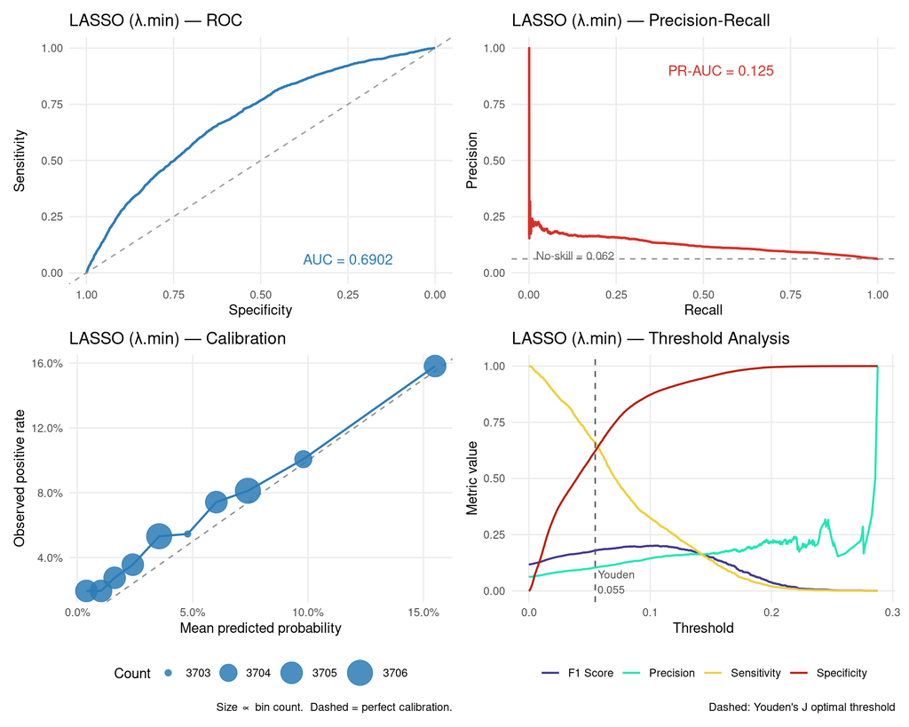

```r
eval_quad_plot(y_test, prob_lasso_min, "LASSO (λ.min)")
```

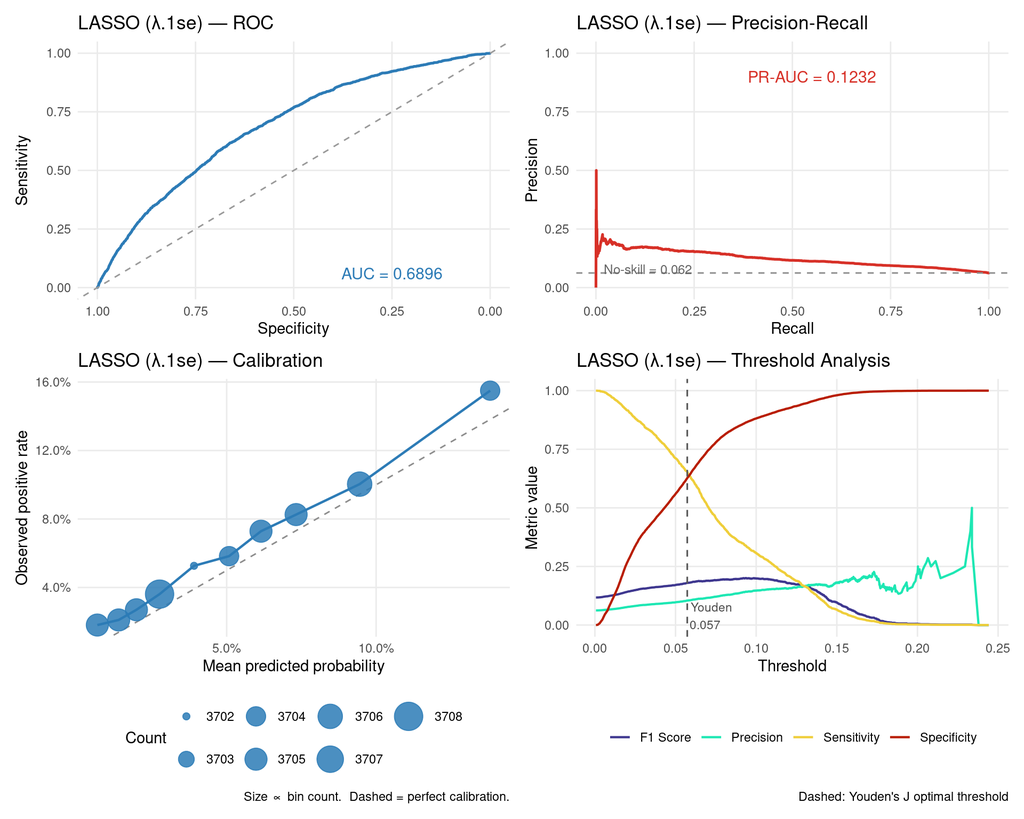

```r
eval_quad_plot(y_test, prob_lasso_1se, "LASSO (λ.1se)")
```

# viii · KNN

## Setup

Two choices shape the training data:

- **Class balance**: equal draws from arrested = 0 and arrested = 1 give KNN balanced local neighbourhoods; without this the dominant class drowns minority-class signal.
- **Size cap (15 000 rows)**: LOO-CV for $k$ selection scales $O(n^2)$ — 15 000 rows makes it tractable.

The test set is evaluated at its original size and class distribution.

## Balanced Downsample and Scaling

We dummy-encode `f_final` via `model.matrix` (same approach as Ridge/LASSO), then scale using training-set statistics so no test information leaks into the scaling step.

```r
set.seed(2026)
idx_pos  <- which(train$arrested == 1)
idx_neg  <- which(train$arrested == 0)
n_per_cl <- min(floor(15000 / 2), length(idx_pos))

# Raw balanced subsample (factor columns still needed for model.matrix)
train_knn_raw <- bind_rows(
  train[sample(idx_pos, n_per_cl), ],
  train[sample(idx_neg, n_per_cl), ]
)

cat(sprintf(
  "KNN training set: %d rows  |  Arrested: %.1f%%  (n_per_class = %d)\n",
  nrow(train_knn_raw), 100 * mean(train_knn_raw$arrested), n_per_cl
))
```

```
## KNN training set: 15000 rows  |  Arrested: 50.0%  (n_per_class = 7500)
```

```r
# Dummy-encode (same columns as ridge/lasso X matrices)
X_knn_tr_raw <- model.matrix(f_final, data = train_knn_raw)[, -1]
X_knn_te_raw <- model.matrix(f_final, data = test)[, -1]

# Scale with train statistics; guard against zero-variance and NA sds
tr_means <- colMeans(X_knn_tr_raw, na.rm = TRUE)
tr_sds   <- apply(X_knn_tr_raw, 2, sd, na.rm = TRUE)
tr_sds[is.na(tr_sds) | tr_sds == 0] <- 1  # constant columns get sd=0 or NA

X_knn_tr <- scale(X_knn_tr_raw, center = tr_means, scale = tr_sds)
X_knn_te <- scale(X_knn_te_raw, center = tr_means, scale = tr_sds)

# Replace any residual NaN (e.g. new factor levels in test not seen in train)
X_knn_tr[!is.finite(X_knn_tr)] <- 0
X_knn_te[!is.finite(X_knn_te)] <- 0

# Sanitise column names (model.matrix can produce names with spaces/brackets)
colnames(X_knn_tr) <- make.names(colnames(X_knn_tr), unique = TRUE)
colnames(X_knn_te) <- make.names(colnames(X_knn_te), unique = TRUE)

# Attach response for kknn formula interface; must be a factor for classification mode
# (integer response triggers regression mode and suppresses the $prob matrix)
resp_levels <- c("0", "1")
df_knn_tr <- as.data.frame(X_knn_tr)
df_knn_tr$arrested <- factor(train_knn_raw$arrested, levels = resp_levels)
df_knn_te <- as.data.frame(X_knn_te)
df_knn_te$arrested <- factor(test$arrested, levels = resp_levels)

f_knn <- arrested ~ .

cat("KNN feature matrix:", nrow(X_knn_tr), "×", ncol(X_knn_tr), "\n")
```

```
## KNN feature matrix: 15000 × 62
```

## k Tuning via LOO-CV

```r
set.seed(2026)
knn_tune <- kknn::train.kknn(
  f_knn, data  = df_knn_tr,
  kmax   = 21,
  kernel = "optimal"
)

best_k <- knn_tune$best.parameters$k
cat("Best k:", best_k, "\n")
```

```
## Best k: 17
```

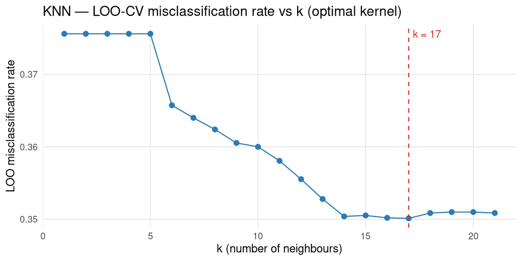

```r
tibble(
  k     = seq_len(21),
  error = as.numeric(knn_tune$MISCLASS[, "optimal"])
) %>%
  ggplot(aes(x = k, y = error)) +
  geom_line(colour = "#2c7bb6") +
  geom_point(colour = "#2c7bb6", size = 2) +
  geom_vline(xintercept = best_k, linetype = "dashed", colour = "#d73027") +
  annotate("text", x = best_k, y = max(as.numeric(knn_tune$MISCLASS[, "optimal"])),
           label = paste0("k = ", best_k), colour = "#d73027",
           hjust = -0.15, size = 3.5) +
  labs(
    x     = "k (number of neighbours)",
    y     = "LOO misclassification rate",
    title = "KNN — LOO-CV misclassification rate vs k (optimal kernel)"
  ) +
  theme_minimal(base_size = 11) +
  theme(panel.grid.minor = element_blank())
```